# Reasonableness_Medians_072025

This is the formal analysis file for the “The Nature of Reasonableness” by by Kevin Tobia, Ivar R. Hannikainen, David Kamper, Guilherme Almeida, Piotr Bystranowski, Niek Strohmaier, Vilius Dranseika, Markus Kneer, Fernando Aguiar, Kristina Dolinina, Bartosz Janik, Eglė Lauraitytė, Alice Liefgreen, Maciej Próchnicki, Alejandro Rosas, Vivek Kumar Shukla, and Noel Struchiner (2025, Stanford Journal of International Law).

## Introduction and Loading of Files

```r
# Load Libraries

library(dplyr)
library(tidyverse)
```

```r
library(stats)
library(ggplot2)
library(ggthemes)
library(corrplot)
library(gridExtra)
library(kableExtra)
library(effects)
library(scales)
DATA_PATH <- "/Users/dgkamper/Library/CloudStorage/GoogleDrive-dgkamper@gmail.com/My Drive/DGK Lab/Collaborations/Language and Law Laboratory/Analysis/LegalResonablenessAnalysis/Data_all_numeric.csv"
```

#### 1. Initial Data Loading and Preparation

```r
# Read the data from specified path
Data_All <- read.csv(DATA_PATH, stringsAsFactors = FALSE)

# Verify data structure
glimpse(Data_All)
```

```
## Rows: 2,426
## Columns: 42
## $ q1             <dbl> 2, 2, 3, 2, 2, 3, 2, 3, 2, 2, 3, 3, 4, 1, 4, 3, 3, 2, 2…
## $ q2             <dbl> 0, 1, 3, 1, 2, 15, 5, 2, 7, 2, 5, 3, 5, 7, 20, 5, 4, 2,…
## $ q3             <dbl> 8, 7, 10, 10, 3, 14, 2, 5, 8, 7, 3, 3, 5, 5, 4, 2, 7, 5…
## $ q4             <dbl> 2500, 2000, 2000, 50, 2000, 1200, 2, 1800, 2000, 1500, …
## $ q5             <dbl> 120, 30, 50, 50, 60, 30, 3, 30, 100, 60, 30, 30, 40, 30…
## $ q6             <dbl> 0, 1, 1, 0, 2, 0, 5, 0, 10, 5, 0, 7, 4, 4, 10, 10, 7, 5…
## $ q7             <chr> "20", "2", "30", "2", "15", "0", "5", "10", "15", "10",…
## $ q8             <dbl> 100, 10, 1, 20, 12, 5, 5, 4, 12, 12, 3, 4, 2, 12, 3, 10…
## $ q9             <dbl> 0, 2, 10, 1, 4, 3, 10, 3, 6, 8, 5, 10, 2, 6, 25, 7, 10,…
## $ q10            <dbl> 3, 50, 5, 5, 3, 1, 4, 1, 8, 0, 0, 10, 1, 1, 2, 0, 1, 1,…
## $ q11            <chr> "0", "1000", "50", "5", "250", "0", "7", "0", "400", "0…
## $ q12            <dbl> 0, 10, 10, 10, 5, 0, 6, 1, 20, 75, 5, 30, 30, 1, 1, 5, …
## $ q13            <dbl> 25, 1, 20, 15, 10, 10, 2, 6, 15, 100, 16, 50, 50, 4, 25…
```

[output cut: 29 more lines]

#### 2. Exclude participants whose answer to Q19 does not equal 15 [comprehension/attention question].

```r
# Split data by condition
Data_All_Average <- Data_All %>% filter(Condition_name == "Average")
Data_All_Ideal <- Data_All %>% filter(Condition_name == "Ideal")
Data_All_Reasonable <- Data_All %>% filter(Condition_name == "Reasonable")

# Exclude participants whose answer to Q19 does not equal 15 [comprehension/attention question].
Data_All_Average_Pass1 <- Data_All_Average %>% filter(q19 == 15)
Data_All_Ideal_Pass1 <- Data_All_Ideal %>% filter(q19 == 15)
Data_All_Reasonable_Pass1 <- Data_All_Reasonable %>% filter(q19 == 15)

# Print participant counts
condition_counts <- data.frame(
  Condition = c("Average", "Ideal", "Reasonable"),
  Original_Count = c(nrow(Data_All_Average), nrow(Data_All_Ideal), nrow(Data_All_Reasonable)),
  After_Attention_Check = c(nrow(Data_All_Average_Pass1), nrow(Data_All_Ideal_Pass1), nrow(Data_All_Reasonable_Pass1)),
  Excluded_Count = c(nrow(Data_All_Average) - nrow(Data_All_Average_Pass1),
                     nrow(Data_All_Ideal) - nrow(Data_All_Ideal_Pass1),
                     nrow(Data_All_Reasonable) - nrow(Data_All_Reasonable_Pass1)),
  Exclusion_Rate = c((nrow(Data_All_Average) - nrow(Data_All_Average_Pass1))/nrow(Data_All_Average),
                     (nrow(Data_All_Ideal) - nrow(Data_All_Ideal_Pass1))/nrow(Data_All_Ideal),
                     (nrow(Data_All_Reasonable) - nrow(Data_All_Reasonable_Pass1))/nrow(Data_All_Reasonable))
)

# Format the exclusion rate as percentage
condition_counts$Exclusion_Rate <- scales::percent(condition_counts$Exclusion_Rate)

# Display the participant counts table
kable(condition_counts, caption = "Participant Counts Before and After Attention Check") %>%
  kable_styling(bootstrap_options = c("striped", "hover", "condensed"), full_width = F)
```

Participant Counts Before and After Attention Check

| Condition | Original_Count | After_Attention_Check | Excluded_Count | Exclusion_Rate |
| --- | --- | --- | --- | --- |
| Average | 815 | 793 | 22 | 2.70% |
| Ideal | 825 | 800 | 25 | 3.03% |
| Reasonable | 786 | 758 | 28 | 3.56% |

```r
# Define the question columns - ensuring they actually exist in the data
question_cols <- c("q1", "q2", "q3", "q4", "q5", "q6", "q7", "q8", "q9", "q10",
                   "q11", "q12", "q13", "q14", "q15", "q16", "q17", "q18",
                   "q20", "q21", "q22", "q23", "q24", "q25", "q26", "q27",
                   "q28", "q29", "q30", "q31", "q32", "q33", "q34")

# Check if all question columns exist in the data
existing_cols <- question_cols[question_cols %in% colnames(Data_All_Average_Pass1)]
missing_cols <- question_cols[!question_cols %in% colnames(Data_All_Average_Pass1)]

print("Existing question columns:")
```

```
## [1] "Existing question columns:"
```

```r
print(existing_cols)
```

```
##  [1] "q1"  "q2"  "q3"  "q4"  "q5"  "q6"  "q7"  "q8"  "q9"  "q10" "q11" "q12"
## [13] "q13" "q14" "q15" "q16" "q17" "q18" "q20" "q21" "q22" "q23" "q24" "q25"
## [25] "q26" "q27" "q28" "q29" "q30" "q31" "q32" "q33" "q34"
```

```r
print("Missing question columns:")
```

```
## [1] "Missing question columns:"
```

```r
print(missing_cols)
```

```
## character(0)
```

#### 3. Check Number of Participants per Condition

```r
# Continue with only the existing columns
question_cols <- existing_cols

# Convert columns to numeric
Data_All_Average_Pass1 <- Data_All_Average_Pass1 %>%
  mutate(across(all_of(question_cols), ~as.numeric(as.character(.))))

Data_All_Ideal_Pass1 <- Data_All_Ideal_Pass1 %>%
  mutate(across(all_of(question_cols), ~as.numeric(as.character(.))))
Data_All_Reasonable_Pass1 <- Data_All_Reasonable_Pass1 %>%
  mutate(across(all_of(question_cols), ~as.numeric(as.character(.))))
# Verify the number of participants in each condition
cat("Ideal condition:", nrow(Data_All_Ideal_Pass1), "participants\n")
```

```
## Ideal condition: 800 participants
```

```r
cat("Average condition:", nrow(Data_All_Average_Pass1), "participants\n")
```

```
## Average condition: 793 participants
```

```r
cat("Reasonable condition:", nrow(Data_All_Reasonable_Pass1), "participants\n")
```

```
## Reasonable condition: 758 participants
```

#### 4a. Filter Data [Due to medians, exclusions of outliers]

No parts to be completed here: done in Analysis 3.

#### 4b. Filter Data [Any response that is > 3SD from QMean, exclude]

```r
# Function to filter data based on 3 SD criterion
filter_data <- function(data, cols) {
  # Pre-allocate a list to track excluded participants for each question
  exclusions_by_question <- list()

  # Original count
  original_count <- nrow(data)

  result <- data
  for (col in cols) {
    if (col %in% colnames(data)) {
      # Calculate mean and standard deviation
      avg <- mean(result[[col]], na.rm = TRUE)
      s <- sd(result[[col]], na.rm = TRUE)

      # Identify outliers
      outlier_indices <- which(!is.na(result[[col]]) & abs(result[[col]] - avg) > 3 * s)
      exclusions_by_question[[col]] <- length(outlier_indices)

      # Filter out outliers
      result <- result %>%
        filter(is.na(!!sym(col)) | abs(!!sym(col) - avg) <= 3 * s)
    }
  }

  # Final count
  final_count <- nrow(result)

  return(list(
    filtered_data = result,
    original_count = original_count,
    final_count = final_count,
    excluded_count = original_count - final_count,
    exclusion_rate = (original_count - final_count) / original_count,
    exclusions_by_question = exclusions_by_question
  ))
}

# Apply filtering and track exclusion counts
avg_filter_results <- filter_data(Data_All_Average_Pass1, question_cols)
ideal_filter_results <- filter_data(Data_All_Ideal_Pass1, question_cols)
reasonable_filter_results <- filter_data(Data_All_Reasonable_Pass1, question_cols)

# Extract the filtered data
Data_All_Average_Filtered <- avg_filter_results$filtered_data
Data_All_Ideal_Filtered <- ideal_filter_results$filtered_data
Data_All_Reasonable_Filtered <- reasonable_filter_results$filtered_data

# Display outlier exclusion summary
outlier_summary <- data.frame(
  Condition = c("Average", "Ideal", "Reasonable"),
  Original_Count = c(avg_filter_results$original_count,
                     ideal_filter_results$original_count,
                     reasonable_filter_results$original_count),
  After_Outlier_Removal = c(avg_filter_results$final_count,
                            ideal_filter_results$final_count,
                            reasonable_filter_results$final_count),
  Excluded_Count = c(avg_filter_results$excluded_count,
                     ideal_filter_results$excluded_count,
                     reasonable_filter_results$excluded_count),
  Exclusion_Rate = c(avg_filter_results$exclusion_rate,
                     ideal_filter_results$exclusion_rate,
                     reasonable_filter_results$exclusion_rate)
)

# Format the exclusion rate as percentage
outlier_summary$Exclusion_Rate <- scales::percent(outlier_summary$Exclusion_Rate)

# Display the outlier exclusion summary table
kable(outlier_summary, caption = "Participant Counts Before and After Outlier Removal") %>%
  kable_styling(bootstrap_options = c("striped", "hover", "condensed"), full_width = F)
```

Participant Counts Before and After Outlier Removal

| Condition | Original_Count | After_Outlier_Removal | Excluded_Count | Exclusion_Rate |
| --- | --- | --- | --- | --- |
| Average | 793 | 609 | 184 | 23.20% |
| Ideal | 800 | 608 | 192 | 24.00% |
| Reasonable | 758 | 590 | 168 | 22.16% |

```r
# Helper functions
get_model_coefs <- function(model) {
  summary_model <- summary(model)
  coef_table <- summary_model$coefficients
  data.frame(
    Term = rownames(coef_table),
    Estimate = coef_table[, "Estimate"],
    Std_Error = coef_table[, "Std. Error"],
    t_value = coef_table[, "t value"],
    p_value = coef_table[, "Pr(>|t|)"]
  )
}

format_pvalue <- function(p_value) {
  if (is.na(p_value)) {
    return("NA")
  } else if (p_value < 0.001) {
    return("< .001")
  } else {
    formatted_p <- sprintf("%.3f", p_value)
    formatted_p <- sub("^0\\.", ".", formatted_p)
    if (formatted_p == "1.000" && p_value < 1) {
        return(".999")
    } else if (formatted_p == "1.000" && p_value >= 1) {
        return("1.000")
    }
    return(formatted_p)
  }
}

log_smallvalue <- function(x) {
  x_safe <- x
  x_safe[which(x == 0 & !is.na(x))] <- 0.01
  log(x_safe)
}

log_plus_one <- function(x) {
  log(x + 1)
}
```

# Analysis 3 [NO 3 SD Removed]: Overall results, with median ratings

#### 1. Compute the median rating

```r
# Calculate medians from attention-check filtered data ONLY
column_medians_average_no3sd <- sapply(Data_All_Average_Pass1[, question_cols], median, na.rm = TRUE)
column_medians_ideal_no3sd <- sapply(Data_All_Ideal_Pass1[, question_cols], median, na.rm = TRUE)
column_medians_reasonable_no3sd <- sapply(Data_All_Reasonable_Pass1[, question_cols], median, na.rm = TRUE)

# Create a dataframe for the medians (NO 3SD)
medians_df_no3sd <- data.frame(
  Question = names(column_medians_average_no3sd),
  Average = column_medians_average_no3sd,
  Ideal = column_medians_ideal_no3sd,
  Reasonable = column_medians_reasonable_no3sd
)

# Display the medians for each question
kable(medians_df_no3sd, caption = "Median Values (NO 3SD Removal)") %>%
  kable_styling(bootstrap_options = c("striped", "hover", "condensed"), full_width = F)
```

Median Values (NO 3SD Removal)

|  | Question | Average | Ideal | Reasonable |
| --- | --- | --- | --- | --- |
| q1 | q1 | 3.0 | 2.0 | 2.0 |
| q2 | q2 | 7.0 | 2.0 | 4.0 |
| q3 | q3 | 3.0 | 6.0 | 5.0 |
| q4 | q4 | 2000.0 | 2000.0 | 2000.0 |
| q5 | q5 | 20.0 | 30.0 | 30.0 |
| q6 | q6 | 10.0 | 1.0 | 3.0 |
| q7 | q7 | 15.0 | 5.0 | 10.0 |
| q8 | q8 | 5.0 | 12.0 | 10.0 |
| q9 | q9 | 5.0 | 3.0 | 5.0 |
| q10 | q10 | 5.0 | 0.0 | 2.0 |
| q11 | q11 | 500.0 | 0.0 | 10.0 |
| q12 | q12 | 30.0 | 1.0 | 10.0 |
| q13 | q13 | 40.0 | 10.0 | 15.0 |
| q14 | q14 | 10.0 | 2.0 | 5.0 |
| q15 | q15 | 9.0 | 10.0 | 8.0 |
| q16 | q16 | 5.0 | 5.0 | 4.0 |
| q17 | q17 | 3.0 | 0.0 | 1.0 |
| q18 | q18 | 15.0 | 2.0 | 9.5 |
| q20 | q20 | 20.0 | 0.0 | 4.0 |
| q21 | q21 | 8.0 | 5.0 | 5.0 |
| q22 | q22 | 10.0 | 7.0 | 7.0 |
| q23 | q23 | 2.0 | 3.0 | 3.0 |
| q24 | q24 | 16.0 | 24.0 | 24.0 |
| q25 | q25 | 2000.0 | 500.0 | 1000.0 |
| q26 | q26 | 8.0 | 2.0 | 4.0 |
| q27 | q27 | 12.0 | 5.0 | 6.0 |
| q28 | q28 | 10.0 | 20.0 | 20.0 |
| q29 | q29 | 55.0 | 90.0 | 80.0 |
| q30 | q30 | 12.0 | 4.0 | 4.0 |
| q31 | q31 | 50.0 | 13.0 | 25.0 |
| q32 | q32 | 24.0 | 48.0 | 40.0 |
| q33 | q33 | 5.5 | 2.5 | 4.0 |
| q34 | q34 | 50.0 | 10.0 | 50.0 |

#### 2a. (Small constant inf values): Convert median responses to a natural log scale (NO 3SD Removal)

```r
# Define Log function: Small constant for zero
log_smallvalue <- function(x) {
  x_safe <- x
  # Replace only actual zeros, leave NAs as NA
  x_safe[which(x == 0 & !is.na(x))] <- 0.01
  log(x_safe)
}

# Apply the log function to NO 3SD medians
log_medians_average_no3sd_smallval <- log_smallvalue(column_medians_average_no3sd)
log_medians_ideal_no3sd_smallval <- log_smallvalue(column_medians_ideal_no3sd)
log_medians_reasonable_no3sd_smallval <- log_smallvalue(column_medians_reasonable_no3sd)

# Create a dataframe for the log medians (NO 3SD, Small Constant)
log_medians_df_no3sd_smallval <- data.frame(
  Question = names(log_medians_average_no3sd_smallval),
  Average = log_medians_average_no3sd_smallval,
  Ideal = log_medians_ideal_no3sd_smallval,
  Reasonable = log_medians_reasonable_no3sd_smallval
)

# Display the log medians
kable(log_medians_df_no3sd_smallval, caption = "Log-Transformed (Small Constant) Median Values (NO 3SD Removal)") %>%
  kable_styling(bootstrap_options = c("striped", "hover", "condensed"), full_width = F)
```

Log-Transformed (Small Constant) Median Values (NO 3SD Removal)

|  | Question | Average | Ideal | Reasonable |
| --- | --- | --- | --- | --- |
| q1 | q1 | 1.0986123 | 0.6931472 | 0.6931472 |
| q2 | q2 | 1.9459101 | 0.6931472 | 1.3862944 |
| q3 | q3 | 1.0986123 | 1.7917595 | 1.6094379 |
| q4 | q4 | 7.6009025 | 7.6009025 | 7.6009025 |
| q5 | q5 | 2.9957323 | 3.4011974 | 3.4011974 |
| q6 | q6 | 2.3025851 | 0.0000000 | 1.0986123 |
| q7 | q7 | 2.7080502 | 1.6094379 | 2.3025851 |
| q8 | q8 | 1.6094379 | 2.4849066 | 2.3025851 |
| q9 | q9 | 1.6094379 | 1.0986123 | 1.6094379 |
| q10 | q10 | 1.6094379 | -4.6051702 | 0.6931472 |
| q11 | q11 | 6.2146081 | -4.6051702 | 2.3025851 |
| q12 | q12 | 3.4011974 | 0.0000000 | 2.3025851 |
| q13 | q13 | 3.6888795 | 2.3025851 | 2.7080502 |
| q14 | q14 | 2.3025851 | 0.6931472 | 1.6094379 |
| q15 | q15 | 2.1972246 | 2.3025851 | 2.0794415 |
| q16 | q16 | 1.6094379 | 1.6094379 | 1.3862944 |
| q17 | q17 | 1.0986123 | -4.6051702 | 0.0000000 |
| q18 | q18 | 2.7080502 | 0.6931472 | 2.2512918 |
| q20 | q20 | 2.9957323 | -4.6051702 | 1.3862944 |
| q21 | q21 | 2.0794415 | 1.6094379 | 1.6094379 |
| q22 | q22 | 2.3025851 | 1.9459101 | 1.9459101 |
| q23 | q23 | 0.6931472 | 1.0986123 | 1.0986123 |
| q24 | q24 | 2.7725887 | 3.1780538 | 3.1780538 |
| q25 | q25 | 7.6009025 | 6.2146081 | 6.9077553 |
| q26 | q26 | 2.0794415 | 0.6931472 | 1.3862944 |
| q27 | q27 | 2.4849066 | 1.6094379 | 1.7917595 |
| q28 | q28 | 2.3025851 | 2.9957323 | 2.9957323 |
| q29 | q29 | 4.0073332 | 4.4998097 | 4.3820266 |
| q30 | q30 | 2.4849066 | 1.3862944 | 1.3862944 |
| q31 | q31 | 3.9120230 | 2.5649494 | 3.2188758 |
| q32 | q32 | 3.1780538 | 3.8712010 | 3.6888795 |
| q33 | q33 | 1.7047481 | 0.9162907 | 1.3862944 |
| q34 | q34 | 3.9120230 | 2.3025851 | 3.9120230 |

#### 2b. (Plus one to all values): Convert median responses to a natural log scale (NO 3SD Removal)

```r
# Define Log function: Add 1
log_plus_one <- function(x) {
  log(x + 1)
}

# Apply the log function to NO 3SD medians
log_medians_average_no3sd_plusone <- log_plus_one(column_medians_average_no3sd)
log_medians_ideal_no3sd_plusone <- log_plus_one(column_medians_ideal_no3sd)
log_medians_reasonable_no3sd_plusone <- log_plus_one(column_medians_reasonable_no3sd)

# Create a dataframe for the log medians (NO 3SD, Plus One)
log_medians_df_no3sd_plusone <- data.frame(
  Question = names(log_medians_average_no3sd_plusone),
  Average = log_medians_average_no3sd_plusone,
  Ideal = log_medians_ideal_no3sd_plusone,
  Reasonable = log_medians_reasonable_no3sd_plusone
)

# Display the log medians
kable(log_medians_df_no3sd_plusone, caption = "Log-Transformed (Plus One) Median Values (NO 3SD Removal)") %>%
  kable_styling(bootstrap_options = c("striped", "hover", "condensed"), full_width = F)
```

Log-Transformed (Plus One) Median Values (NO 3SD Removal)

|  | Question | Average | Ideal | Reasonable |
| --- | --- | --- | --- | --- |
| q1 | q1 | 1.386294 | 1.0986123 | 1.0986123 |
| q2 | q2 | 2.079442 | 1.0986123 | 1.6094379 |
| q3 | q3 | 1.386294 | 1.9459101 | 1.7917595 |
| q4 | q4 | 7.601402 | 7.6014023 | 7.6014023 |
| q5 | q5 | 3.044522 | 3.4339872 | 3.4339872 |
| q6 | q6 | 2.397895 | 0.6931472 | 1.3862944 |
| q7 | q7 | 2.772589 | 1.7917595 | 2.3978953 |
| q8 | q8 | 1.791759 | 2.5649494 | 2.3978953 |
| q9 | q9 | 1.791759 | 1.3862944 | 1.7917595 |
| q10 | q10 | 1.791759 | 0.0000000 | 1.0986123 |
| q11 | q11 | 6.216606 | 0.0000000 | 2.3978953 |
| q12 | q12 | 3.433987 | 0.6931472 | 2.3978953 |
| q13 | q13 | 3.713572 | 2.3978953 | 2.7725887 |
| q14 | q14 | 2.397895 | 1.0986123 | 1.7917595 |
| q15 | q15 | 2.302585 | 2.3978953 | 2.1972246 |
| q16 | q16 | 1.791759 | 1.7917595 | 1.6094379 |
| q17 | q17 | 1.386294 | 0.0000000 | 0.6931472 |
| q18 | q18 | 2.772589 | 1.0986123 | 2.3513753 |
| q20 | q20 | 3.044522 | 0.0000000 | 1.6094379 |
| q21 | q21 | 2.197225 | 1.7917595 | 1.7917595 |
| q22 | q22 | 2.397895 | 2.0794415 | 2.0794415 |
| q23 | q23 | 1.098612 | 1.3862944 | 1.3862944 |
| q24 | q24 | 2.833213 | 3.2188758 | 3.2188758 |
| q25 | q25 | 7.601402 | 6.2166061 | 6.9087548 |
| q26 | q26 | 2.197225 | 1.0986123 | 1.6094379 |
| q27 | q27 | 2.564949 | 1.7917595 | 1.9459101 |
| q28 | q28 | 2.397895 | 3.0445224 | 3.0445224 |
| q29 | q29 | 4.025352 | 4.5108595 | 4.3944492 |
| q30 | q30 | 2.564949 | 1.6094379 | 1.6094379 |
| q31 | q31 | 3.931826 | 2.6390573 | 3.2580965 |
| q32 | q32 | 3.218876 | 3.8918203 | 3.7135721 |
| q33 | q33 | 1.871802 | 1.2527630 | 1.6094379 |
| q34 | q34 | 3.931826 | 2.3978953 | 3.9318256 |

#### 3a. (Small constant inf values): Conduct three regressions and record AIC (NO 3SD Removal)

```r
# Create data frame for regression (NO 3SD, Small Constant)
dataforAICMedians_no3sd_smallval <- data.frame(
  Reasonable = log_medians_reasonable_no3sd_smallval,
  Average = log_medians_average_no3sd_smallval,
  Ideal = log_medians_ideal_no3sd_smallval
)

# Filter out rows with non-finite values before regression
dataforAICMedians_no3sd_smallval_clean <- dataforAICMedians_no3sd_smallval %>%
  filter(is.finite(Reasonable) & is.finite(Average) & is.finite(Ideal))

# Check if enough data points remain
if(nrow(dataforAICMedians_no3sd_smallval_clean) > 3) {

  # Model I
  Model1Medians_no3sd_smallval <- lm(Reasonable ~ Average, data = dataforAICMedians_no3sd_smallval_clean)
  AIC1Medians_no3sd_smallval <- AIC(Model1Medians_no3sd_smallval)
  r2_model1_median_no3sd_smallval <- summary(Model1Medians_no3sd_smallval)$r.squared

  # Model II
  Model2Medians_no3sd_smallval <- lm(Reasonable ~ Ideal, data = dataforAICMedians_no3sd_smallval_clean)
  AIC2Medians_no3sd_smallval <- AIC(Model2Medians_no3sd_smallval)
  r2_model2_median_no3sd_smallval <- summary(Model2Medians_no3sd_smallval)$r.squared

  # Model III
  Model3Medians_no3sd_smallval <- lm(Reasonable ~ Average + Ideal, data = dataforAICMedians_no3sd_smallval_clean)
  AIC3Medians_no3sd_smallval <- AIC(Model3Medians_no3sd_smallval)
  r2_model3_median_no3sd_smallval <- summary(Model3Medians_no3sd_smallval)$r.squared

  # Create a regression summary dataframe
  regression_summary_medians_no3sd_smallval <- data.frame(
    Model = c("Average predicts Reasonable",
              "Ideal predicts Reasonable",
              "Average + Ideal predict Reasonable"),
    AIC = c(AIC1Medians_no3sd_smallval, AIC2Medians_no3sd_smallval, AIC3Medians_no3sd_smallval),
    R_squared = c(r2_model1_median_no3sd_smallval, r2_model2_median_no3sd_smallval, r2_model3_median_no3sd_smallval)
  )

  # Display the regression summary table
  kable(regression_summary_medians_no3sd_smallval, caption = "Regression Comparison (Median, NO 3SD, Log Small Constant)") %>%
    kable_styling(bootstrap_options = c("striped", "hover", "condensed"), full_width = F)

} else {
  cat("Not enough valid data points for regression (NO 3SD, Log Small Constant).\n")
  regression_summary_medians_no3sd_smallval <- data.frame(Model=character(), AIC=numeric(), R_squared=numeric())
}
```

Regression Comparison (Median, NO 3SD, Log Small Constant)

| Model | AIC | R_squared |
| --- | --- | --- |
| Average predicts Reasonable | 85.96537 | 0.7350584 |
| Ideal predicts Reasonable | 102.37505 | 0.5643791 |
| Average + Ideal predict Reasonable | 39.38395 | 0.9392149 |

#### 3b. (Plus one to all values): Conduct three regressions and record AIC (NO 3SD Removal)

```r
# Create data frame for regression (NO 3SD, Plus One)
dataforAICMedians_no3sd_plusone <- data.frame(
  Reasonable = log_medians_reasonable_no3sd_plusone,
  Average = log_medians_average_no3sd_plusone,
  Ideal = log_medians_ideal_no3sd_plusone
)

# Filter out rows with non-finite values before regression
dataforAICMedians_no3sd_plusone_clean <- dataforAICMedians_no3sd_plusone %>%
  filter(is.finite(Reasonable) & is.finite(Average) & is.finite(Ideal))

# Check if enough data points remain
if(nrow(dataforAICMedians_no3sd_plusone_clean) > 3) {

  # Model I
  Model1Medians_no3sd_plusone <- lm(Reasonable ~ Average, data = dataforAICMedians_no3sd_plusone_clean)
  AIC1Medians_no3sd_plusone <- AIC(Model1Medians_no3sd_plusone)
  r2_model1_median_no3sd_plusone <- summary(Model1Medians_no3sd_plusone)$r.squared

  # Model II
  Model2Medians_no3sd_plusone <- lm(Reasonable ~ Ideal, data = dataforAICMedians_no3sd_plusone_clean)
  AIC2Medians_no3sd_plusone <- AIC(Model2Medians_no3sd_plusone)
  r2_model2_median_no3sd_plusone <- summary(Model2Medians_no3sd_plusone)$r.squared

  # Model III
  Model3Medians_no3sd_plusone <- lm(Reasonable ~ Average + Ideal, data = dataforAICMedians_no3sd_plusone_clean)
  AIC3Medians_no3sd_plusone <- AIC(Model3Medians_no3sd_plusone)
  r2_model3_median_no3sd_plusone <- summary(Model3Medians_no3sd_plusone)$r.squared

  # Create a regression summary dataframe
  regression_summary_medians_no3sd_plusone <- data.frame(
    Model = c("Average predicts Reasonable",
              "Ideal predicts Reasonable",
              "Average + Ideal predict Reasonable"),
    AIC = c(AIC1Medians_no3sd_plusone, AIC2Medians_no3sd_plusone, AIC3Medians_no3sd_plusone),
    R_squared = c(r2_model1_median_no3sd_plusone, r2_model2_median_no3sd_plusone, r2_model3_median_no3sd_plusone)
  )

  # Display the regression summary table
  kable(regression_summary_medians_no3sd_plusone, caption = "Regression Comparison (Median, NO 3SD, Log Plus One)") %>%
    kable_styling(bootstrap_options = c("striped", "hover", "condensed"), full_width = F)

} else {
   cat("Not enough valid data points for regression (NO 3SD, Log Plus One).\n")
   regression_summary_medians_no3sd_plusone <- data.frame(Model=character(), AIC=numeric(), R_squared=numeric())
}
```

Regression Comparison (Median, NO 3SD, Log Plus One)

| Model | AIC | R_squared |
| --- | --- | --- |
| Average predicts Reasonable | 80.731562 | 0.7415783 |
| Ideal predicts Reasonable | 62.561052 | 0.8509963 |
| Average + Ideal predict Reasonable | 9.982732 | 0.9714949 |

#### 4a. (Small constant inf values): Plots and Reporting (NO 3SD Removal)

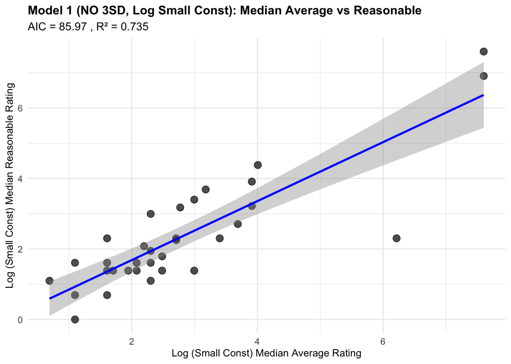

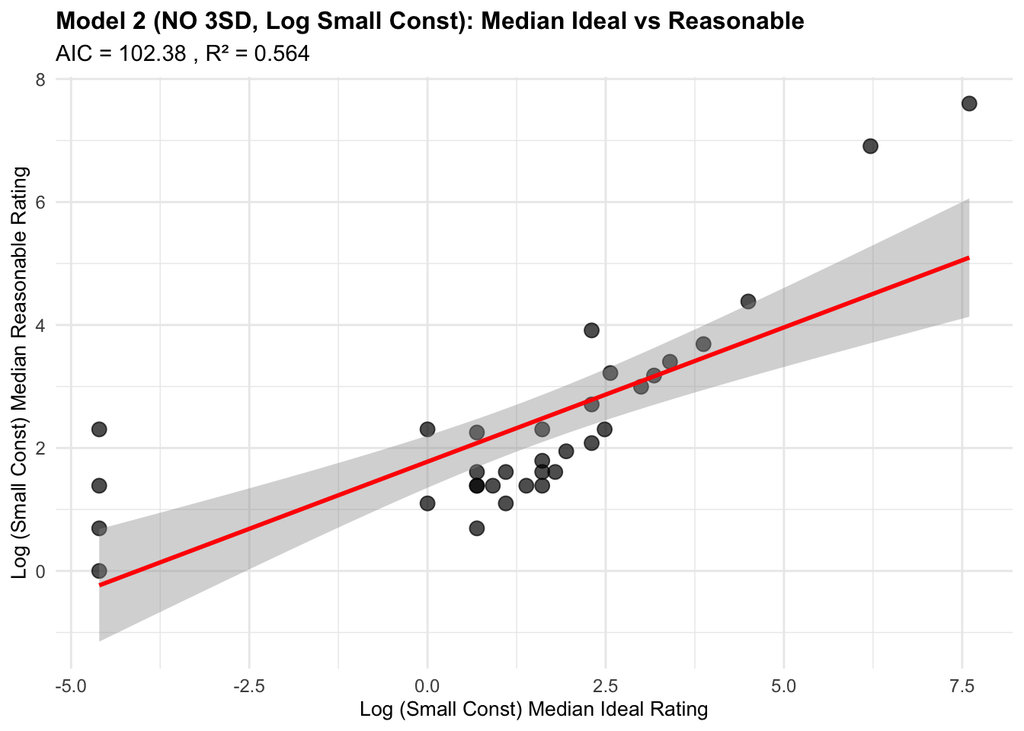

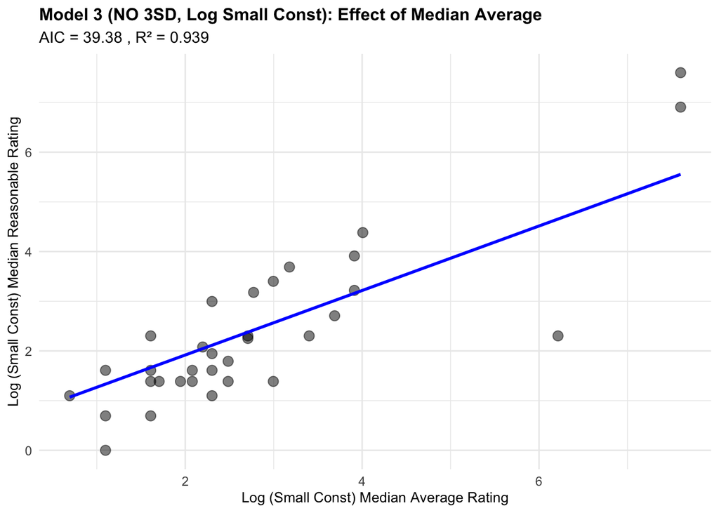

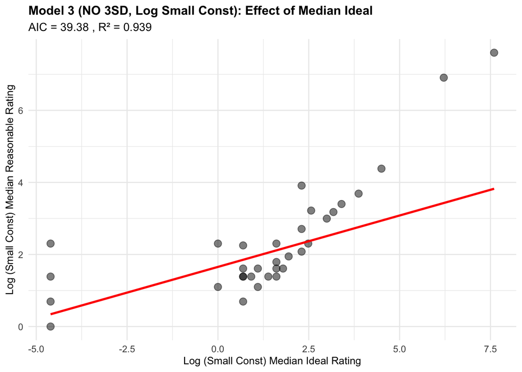

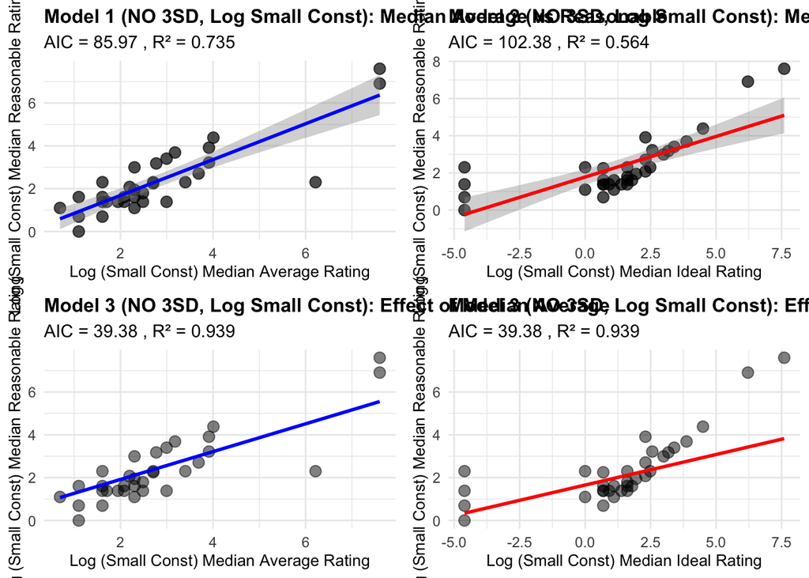

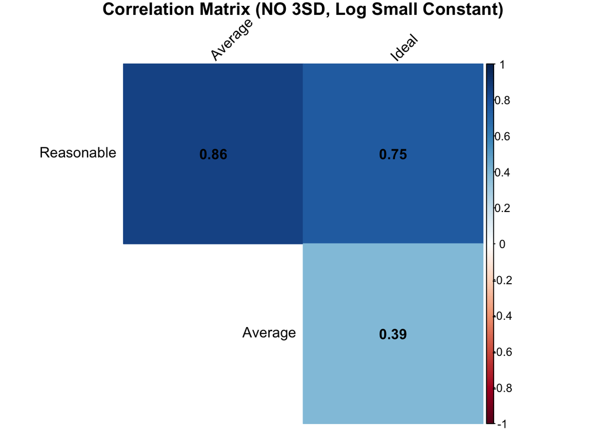

```
##
## Model Summaries (NO 3SD, Log Small Constant):
##
## Call:
## lm(formula = Reasonable ~ Average, data = dataforAICMedians_no3sd_smallval_clean)
##
## Residuals:
##      Min       1Q   Median       3Q      Max
## -2.90856 -0.36496 -0.02592  0.62745  1.22985
##
## Coefficients:
##             Estimate Std. Error t value Pr(>|t|)
## (Intercept)  0.01139    0.29154   0.039    0.969
## Average      0.83670    0.09022   9.274 1.88e-10 ***
## ---
## Signif. codes:  0 '***' 0.001 '**' 0.01 '*' 0.05 '.' 0.1 ' ' 1
##
## Residual standard error: 0.8385 on 31 degrees of freedom
## Multiple R-squared:  0.7351, Adjusted R-squared:  0.7265
## F-statistic: 86.01 on 1 and 31 DF,  p-value: 1.878e-10
##
##
## Call:
## lm(formula = Reasonable ~ Ideal, data = dataforAICMedians_no3sd_smallval_clean)
##
## Residuals:
##     Min      1Q  Median      3Q     Max
## -1.3866 -0.6934 -0.1773  0.3218  2.5365
##
## Coefficients:
##             Estimate Std. Error t value Pr(>|t|)
## (Intercept)   1.7771     0.2080   8.544 1.19e-09 ***
## Ideal         0.4367     0.0689   6.337 4.72e-07 ***
## ---
## Signif. codes:  0 '***' 0.001 '**' 0.01 '*' 0.05 '.' 0.1 ' ' 1
##
## Residual standard error: 1.075 on 31 degrees of freedom
## Multiple R-squared:  0.5644, Adjusted R-squared:  0.5503
## F-statistic: 40.16 on 1 and 31 DF,  p-value: 4.715e-07
##
##
## Call:
## lm(formula = Reasonable ~ Average + Ideal, data = dataforAICMedians_no3sd_smallval_clean)
##
## Residuals:
##      Min       1Q   Median       3Q      Max
## -0.78273 -0.27802 -0.06571  0.33604  0.80237
##
## Coefficients:
##             Estimate Std. Error t value Pr(>|t|)
## (Intercept)  0.16010    0.14273   1.122    0.271
## Average      0.64924    0.04773  13.601 2.29e-14 ***
## Ideal        0.28538    0.02843  10.038 4.19e-11 ***
## ---
## Signif. codes:  0 '***' 0.001 '**' 0.01 '*' 0.05 '.' 0.1 ' ' 1
##
## Residual standard error: 0.4083 on 30 degrees of freedom
## Multiple R-squared:  0.9392, Adjusted R-squared:  0.9352
## F-statistic: 231.8 on 2 and 30 DF,  p-value: < 2.2e-16
```

```r
# Check if models exist before plotting
if(exists("Model1Medians_no3sd_smallval") && exists("dataforAICMedians_no3sd_smallval_clean") && nrow(dataforAICMedians_no3sd_smallval_clean) > 0) {

  # Average Median vs Reasonable Median
  plot1_median_no3sd_smallval <- ggplot(dataforAICMedians_no3sd_smallval_clean, aes(x = Average, y = Reasonable)) +
    geom_point(size = 3, alpha = 0.7) + geom_smooth(method = "lm", se = TRUE, color = "blue") +
    labs(title = "Model 1 (NO 3SD, Log Small Const): Median Average vs Reasonable",
         subtitle = paste("AIC =", round(AIC1Medians_no3sd_smallval, 2), ", R² =", round(r2_model1_median_no3sd_smallval, 3)),
         x = "Log (Small Const) Median Average Rating", y = "Log (Small Const) Median Reasonable Rating") +
    theme_minimal() + theme( plot.title = element_text(size = 12, face = "bold"), plot.subtitle = element_text(size = 11), axis.title = element_text(size = 10), axis.text = element_text(size = 9) )

  # Ideal Median vs Reasonable Median
  plot2_median_no3sd_smallval <- ggplot(dataforAICMedians_no3sd_smallval_clean, aes(x = Ideal, y = Reasonable)) +
    geom_point(size = 3, alpha = 0.7) + geom_smooth(method = "lm", se = TRUE, color = "red") +
    labs(title = "Model 2 (NO 3SD, Log Small Const): Median Ideal vs Reasonable",
         subtitle = paste("AIC =", round(AIC2Medians_no3sd_smallval, 2), ", R² =", round(r2_model2_median_no3sd_smallval, 3)),
         x = "Log (Small Const) Median Ideal Rating", y = "Log (Small Const) Median Reasonable Rating") +
    theme_minimal() + theme( plot.title = element_text(size = 12, face = "bold"), plot.subtitle = element_text(size = 11), axis.title = element_text(size = 10), axis.text = element_text(size = 9) )

  # Model 3 (Average effect)
  new_data_median_no3sd_smallval <- expand.grid( Average = seq(min(dataforAICMedians_no3sd_smallval_clean$Average, na.rm=TRUE), max(dataforAICMedians_no3sd_smallval_clean$Average, na.rm=TRUE), length.out = 100), Ideal = median(dataforAICMedians_no3sd_smallval_clean$Ideal, na.rm=TRUE) )
  new_data_median_no3sd_smallval <- new_data_median_no3sd_smallval[is.finite(new_data_median_no3sd_smallval$Average) & is.finite(new_data_median_no3sd_smallval$Ideal),]
  if(nrow(new_data_median_no3sd_smallval)>0){ new_data_median_no3sd_smallval$predicted_reasonable <- predict(Model3Medians_no3sd_smallval, newdata = new_data_median_no3sd_smallval) } else { new_data_median_no3sd_smallval <- data.frame(Average=numeric(), Ideal=numeric(), predicted_reasonable=numeric())}
  plot3_median_no3sd_smallval <- ggplot(dataforAICMedians_no3sd_smallval_clean, aes(x = Average, y = Reasonable)) + geom_point(size = 3, alpha = 0.5) + geom_line(data = new_data_median_no3sd_smallval, aes(y = predicted_reasonable), color = "blue", size = 1) + labs(title = "Model 3 (NO 3SD, Log Small Const): Effect of Median Average", subtitle = paste("AIC =", round(AIC3Medians_no3sd_smallval, 2), ", R² =", round(r2_model3_median_no3sd_smallval, 3)), x = "Log (Small Const) Median Average Rating", y = "Log (Small Const) Median Reasonable Rating") + theme_minimal() + theme( plot.title = element_text(size = 12, face = "bold"), plot.subtitle = element_text(size = 11), axis.title = element_text(size = 10), axis.text = element_text(size = 9) )

  # Model 3 (Ideal effect)
  new_data2_median_no3sd_smallval <- expand.grid( Average = median(dataforAICMedians_no3sd_smallval_clean$Average, na.rm=TRUE), Ideal = seq(min(dataforAICMedians_no3sd_smallval_clean$Ideal, na.rm=TRUE), max(dataforAICMedians_no3sd_smallval_clean$Ideal, na.rm=TRUE), length.out = 100) )
  new_data2_median_no3sd_smallval <- new_data2_median_no3sd_smallval[is.finite(new_data2_median_no3sd_smallval$Average) & is.finite(new_data2_median_no3sd_smallval$Ideal),]
  if(nrow(new_data2_median_no3sd_smallval)>0){ new_data2_median_no3sd_smallval$predicted_reasonable <- predict(Model3Medians_no3sd_smallval, newdata = new_data2_median_no3sd_smallval) } else { new_data2_median_no3sd_smallval <- data.frame(Average=numeric(), Ideal=numeric(), predicted_reasonable=numeric())}
  plot4_median_no3sd_smallval <- ggplot(dataforAICMedians_no3sd_smallval_clean, aes(x = Ideal, y = Reasonable)) + geom_point(size = 3, alpha = 0.5) + geom_line(data = new_data2_median_no3sd_smallval, aes(y = predicted_reasonable), color = "red", size = 1) + labs(title = "Model 3 (NO 3SD, Log Small Const): Effect of Median Ideal", subtitle = paste("AIC =", round(AIC3Medians_no3sd_smallval, 2), ", R² =", round(r2_model3_median_no3sd_smallval, 3)), x = "Log (Small Const) Median Ideal Rating", y = "Log (Small Const) Median Reasonable Rating") + theme_minimal() + theme( plot.title = element_text(size = 12, face = "bold"), plot.subtitle = element_text(size = 11), axis.title = element_text(size = 10), axis.text = element_text(size = 9) )

  # Display plots
  print(plot1_median_no3sd_smallval)
  print(plot2_median_no3sd_smallval)
  print(plot3_median_no3sd_smallval)
  print(plot4_median_no3sd_smallval)

  # Save plots
  ggsave("model1_median_avg_reas_no3sd_smallval.png", plot1_median_no3sd_smallval, width = 8, height = 6, dpi = 300)
  ggsave("model2_median_ideal_reas_no3sd_smallval.png", plot2_median_no3sd_smallval, width = 8, height = 6, dpi = 300)
  ggsave("model3_median_avg_eff_no3sd_smallval.png", plot3_median_no3sd_smallval, width = 8, height = 6, dpi = 300)
  ggsave("model3_median_ideal_eff_no3sd_smallval.png", plot4_median_no3sd_smallval, width = 8, height = 6, dpi = 300)
  grid_plots_median_no3sd_smallval <- grid.arrange(plot1_median_no3sd_smallval, plot2_median_no3sd_smallval, plot3_median_no3sd_smallval, plot4_median_no3sd_smallval, ncol = 2)
  ggsave("all_median_plots_no3sd_smallval.png", grid_plots_median_no3sd_smallval, width = 14, height = 10, dpi = 300)

  # Correlation matrix
  cor_data_no3sd_smallval <- dataforAICMedians_no3sd_smallval_clean[complete.cases(dataforAICMedians_no3sd_smallval_clean),]
  if(nrow(cor_data_no3sd_smallval) > 1) {
   cor_matrix_no3sd_smallval <- cor(cor_data_no3sd_smallval, use = "complete.obs")
   corrplot(cor_matrix_no3sd_smallval, method = "color", type = "upper", addCoef.col = "black", tl.col = "black", tl.srt = 45, diag = FALSE, title = "Correlation Matrix (NO 3SD, Log Small Constant)", mar = c(0,0,1,0))
  } else { cat("Not enough data for correlation matrix (NO 3SD, Log Small Constant).\n") }

  # Coefficient tables
  model1_coefs_no3sd_smallval <- get_model_coefs(Model1Medians_no3sd_smallval)
  model2_coefs_no3sd_smallval <- get_model_coefs(Model2Medians_no3sd_smallval)
  model3_coefs_no3sd_smallval <- get_model_coefs(Model3Medians_no3sd_smallval)
  model1_coefs_no3sd_smallval$p_value <- sapply(model1_coefs_no3sd_smallval$p_value, format_pvalue)
  model2_coefs_no3sd_smallval$p_value <- sapply(model2_coefs_no3sd_smallval$p_value, format_pvalue)
  model3_coefs_no3sd_smallval$p_value <- sapply(model3_coefs_no3sd_smallval$p_value, format_pvalue)
  kable(model1_coefs_no3sd_smallval, caption = "Model 1 Coeffs (NO 3SD, Log Small Const)") %>% kable_styling(bootstrap_options = c("striped", "hover", "condensed"), full_width = F)
  kable(model2_coefs_no3sd_smallval, caption = "Model 2 Coeffs (NO 3SD, Log Small Const)") %>% kable_styling(bootstrap_options = c("striped", "hover", "condensed"), full_width = F)
  kable(model3_coefs_no3sd_smallval, caption = "Model 3 Coeffs (NO 3SD, Log Small Const)") %>% kable_styling(bootstrap_options = c("striped", "hover", "condensed"), full_width = F)

  # Print model summaries
  cat("\nModel Summaries (NO 3SD, Log Small Constant):\n")
  print(summary(Model1Medians_no3sd_smallval))
  print(summary(Model2Medians_no3sd_smallval))
  print(summary(Model3Medians_no3sd_smallval))

} else {
   cat("Skipping plots and summaries for (NO 3SD, Log Small Constant) due to insufficient data.\n")
}
```

```r
# Store results
analysis_3_results_no3sd_smallval <- list(
  medians_by_question = if(exists("medians_df_no3sd")) medians_df_no3sd else NULL,
  log_medians_by_question = if(exists("log_medians_df_no3sd_smallval")) log_medians_df_no3sd_smallval else NULL,
  regression_models = if(exists("Model1Medians_no3sd_smallval")) list(model1 = Model1Medians_no3sd_smallval, model2 = Model2Medians_no3sd_smallval, model3 = Model3Medians_no3sd_smallval) else NULL,
  regression_summary = if(exists("regression_summary_medians_no3sd_smallval")) regression_summary_medians_no3sd_smallval else NULL,
  aic_values = if(exists("AIC1Medians_no3sd_smallval")) c(AIC1 = AIC1Medians_no3sd_smallval, AIC2 = AIC2Medians_no3sd_smallval, AIC3 = AIC3Medians_no3sd_smallval) else NULL
)
```

#### 4b. (Plus one to all values): Plots and Reporting (NO 3SD Removal)

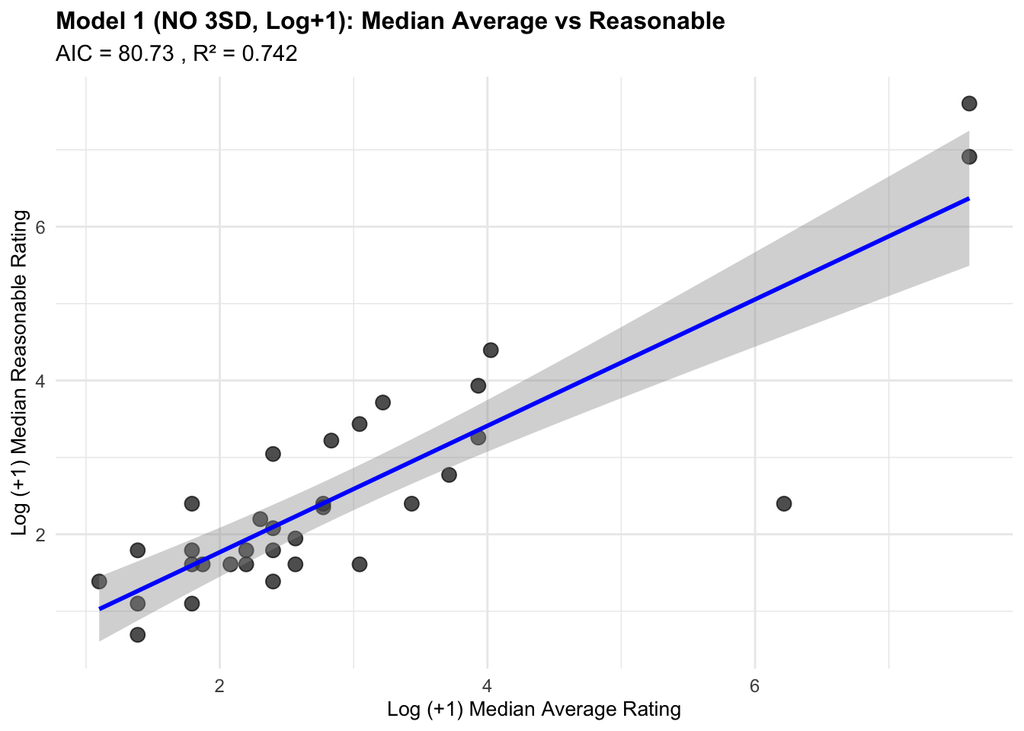

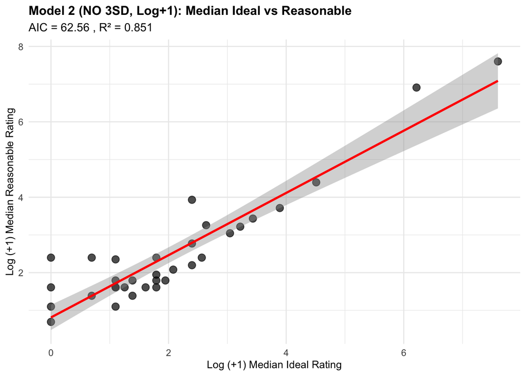

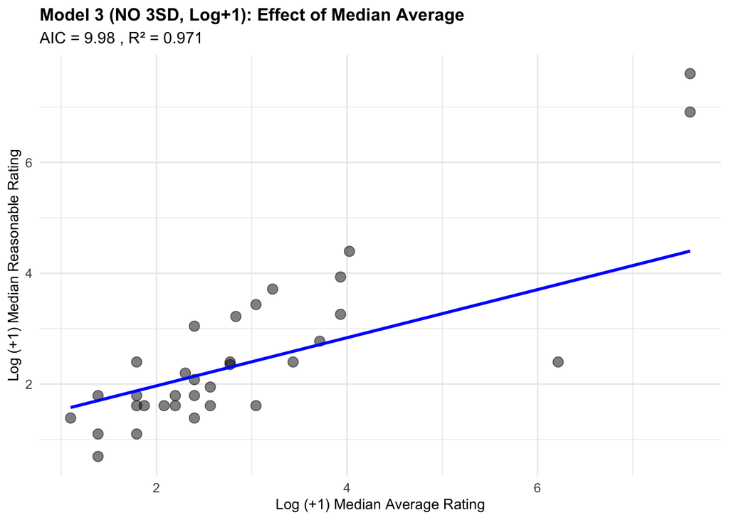

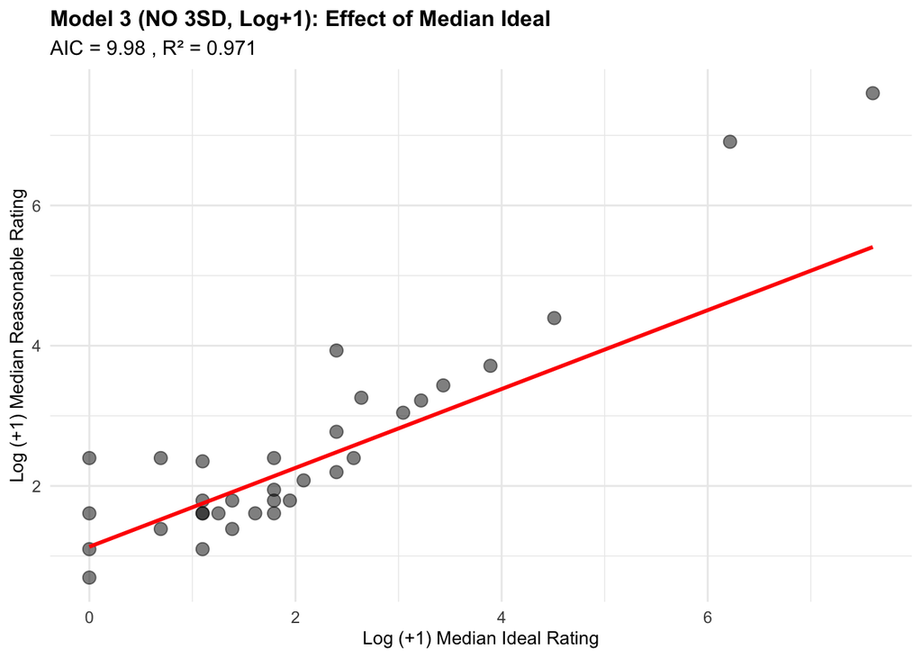

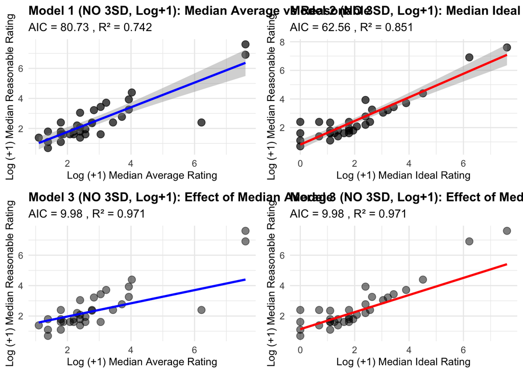

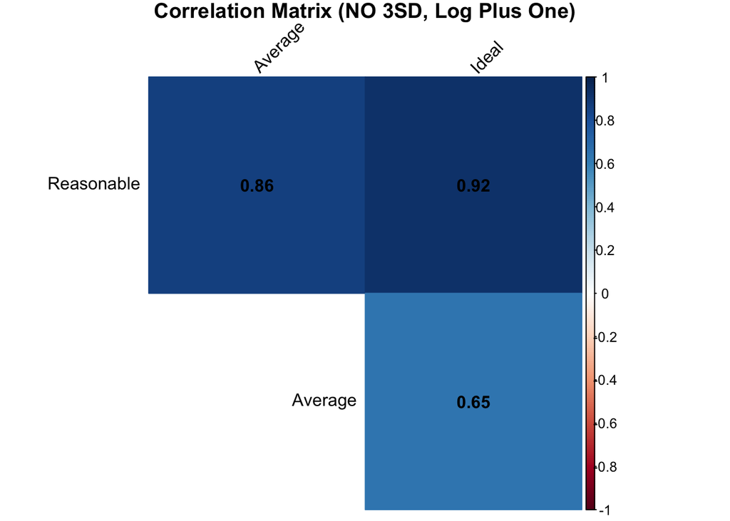

```
##
## Model Summaries (NO 3SD, Log Plus One):
##
## Call:
## lm(formula = Reasonable ~ Average, data = dataforAICMedians_no3sd_plusone_clean)
##
## Residuals:
##      Min       1Q   Median       3Q      Max
## -2.83433 -0.32028 -0.05108  0.53872  1.23137
##
## Coefficients:
##             Estimate Std. Error t value Pr(>|t|)
## (Intercept)  0.12437    0.28692   0.433    0.668
## Average      0.82165    0.08711   9.432 1.27e-10 ***
## ---
## Signif. codes:  0 '***' 0.001 '**' 0.01 '*' 0.05 '.' 0.1 ' ' 1
##
## Residual standard error: 0.7746 on 31 degrees of freedom
## Multiple R-squared:  0.7416, Adjusted R-squared:  0.7332
## F-statistic: 88.96 on 1 and 31 DF,  p-value: 1.271e-10
##
##
## Call:
## lm(formula = Reasonable ~ Ideal, data = dataforAICMedians_no3sd_plusone_clean)
##
## Residuals:
##     Min      1Q  Median      3Q     Max
## -0.6811 -0.4486 -0.1409  0.2681  1.5866
##
## Coefficients:
##             Estimate Std. Error t value Pr(>|t|)
## (Intercept)  0.81133    0.16383   4.952 2.46e-05 ***
## Ideal        0.82556    0.06204  13.306 2.34e-14 ***
## ---
## Signif. codes:  0 '***' 0.001 '**' 0.01 '*' 0.05 '.' 0.1 ' ' 1
##
## Residual standard error: 0.5882 on 31 degrees of freedom
## Multiple R-squared:  0.851,  Adjusted R-squared:  0.8462
## F-statistic:   177 on 1 and 31 DF,  p-value: 2.345e-14
##
##
## Call:
## lm(formula = Reasonable ~ Average + Ideal, data = dataforAICMedians_no3sd_plusone_clean)
##
## Residuals:
##      Min       1Q   Median       3Q      Max
## -0.50094 -0.21285  0.00378  0.08933  0.78470
##
## Coefficients:
##             Estimate Std. Error t value Pr(>|t|)
## (Intercept)  0.09186    0.09689   0.948    0.351
## Average      0.43408    0.03855  11.261 2.68e-12 ***
## Ideal        0.56239    0.03615  15.556 6.64e-16 ***
## ---
## Signif. codes:  0 '***' 0.001 '**' 0.01 '*' 0.05 '.' 0.1 ' ' 1
##
## Residual standard error: 0.2615 on 30 degrees of freedom
## Multiple R-squared:  0.9715, Adjusted R-squared:  0.9696
## F-statistic: 511.2 on 2 and 30 DF,  p-value: < 2.2e-16
```

```r
# Check if models exist before plotting
if(exists("Model1Medians_no3sd_plusone") && exists("dataforAICMedians_no3sd_plusone_clean") && nrow(dataforAICMedians_no3sd_plusone_clean) > 0) {

  # Average Median vs Reasonable Median
  plot1_median_no3sd_plusone <- ggplot(dataforAICMedians_no3sd_plusone_clean, aes(x = Average, y = Reasonable)) +
    geom_point(size = 3, alpha = 0.7) + geom_smooth(method = "lm", se = TRUE, color = "blue") +
    labs(title = "Model 1 (NO 3SD, Log+1): Median Average vs Reasonable",
         subtitle = paste("AIC =", round(AIC1Medians_no3sd_plusone, 2), ", R² =", round(r2_model1_median_no3sd_plusone, 3)),
         x = "Log (+1) Median Average Rating", y = "Log (+1) Median Reasonable Rating") +
    theme_minimal() + theme( plot.title = element_text(size = 12, face = "bold"), plot.subtitle = element_text(size = 11), axis.title = element_text(size = 10), axis.text = element_text(size = 9) )

  # Ideal Median vs Reasonable Median
  plot2_median_no3sd_plusone <- ggplot(dataforAICMedians_no3sd_plusone_clean, aes(x = Ideal, y = Reasonable)) +
    geom_point(size = 3, alpha = 0.7) + geom_smooth(method = "lm", se = TRUE, color = "red") +
    labs(title = "Model 2 (NO 3SD, Log+1): Median Ideal vs Reasonable",
         subtitle = paste("AIC =", round(AIC2Medians_no3sd_plusone, 2), ", R² =", round(r2_model2_median_no3sd_plusone, 3)),
         x = "Log (+1) Median Ideal Rating", y = "Log (+1) Median Reasonable Rating") +
    theme_minimal() + theme( plot.title = element_text(size = 12, face = "bold"), plot.subtitle = element_text(size = 11), axis.title = element_text(size = 10), axis.text = element_text(size = 9) )

  # Model 3 (Average effect)
  new_data_median_no3sd_plusone <- expand.grid( Average = seq(min(dataforAICMedians_no3sd_plusone_clean$Average, na.rm=TRUE), max(dataforAICMedians_no3sd_plusone_clean$Average, na.rm=TRUE), length.out = 100), Ideal = median(dataforAICMedians_no3sd_plusone_clean$Ideal, na.rm=TRUE) )
  new_data_median_no3sd_plusone <- new_data_median_no3sd_plusone[is.finite(new_data_median_no3sd_plusone$Average) & is.finite(new_data_median_no3sd_plusone$Ideal),]
  if(nrow(new_data_median_no3sd_plusone)>0){ new_data_median_no3sd_plusone$predicted_reasonable <- predict(Model3Medians_no3sd_plusone, newdata = new_data_median_no3sd_plusone) } else { new_data_median_no3sd_plusone <- data.frame(Average=numeric(), Ideal=numeric(), predicted_reasonable=numeric())}
  plot3_median_no3sd_plusone <- ggplot(dataforAICMedians_no3sd_plusone_clean, aes(x = Average, y = Reasonable)) + geom_point(size = 3, alpha = 0.5) + geom_line(data = new_data_median_no3sd_plusone, aes(y = predicted_reasonable), color = "blue", size = 1) + labs(title = "Model 3 (NO 3SD, Log+1): Effect of Median Average", subtitle = paste("AIC =", round(AIC3Medians_no3sd_plusone, 2), ", R² =", round(r2_model3_median_no3sd_plusone, 3)), x = "Log (+1) Median Average Rating", y = "Log (+1) Median Reasonable Rating") + theme_minimal() + theme( plot.title = element_text(size = 12, face = "bold"), plot.subtitle = element_text(size = 11), axis.title = element_text(size = 10), axis.text = element_text(size = 9) )

  # Model 3 (Ideal effect)
  new_data2_median_no3sd_plusone <- expand.grid( Average = median(dataforAICMedians_no3sd_plusone_clean$Average, na.rm=TRUE), Ideal = seq(min(dataforAICMedians_no3sd_plusone_clean$Ideal, na.rm=TRUE), max(dataforAICMedians_no3sd_plusone_clean$Ideal, na.rm=TRUE), length.out = 100) )
  new_data2_median_no3sd_plusone <- new_data2_median_no3sd_plusone[is.finite(new_data2_median_no3sd_plusone$Average) & is.finite(new_data2_median_no3sd_plusone$Ideal),]
  if(nrow(new_data2_median_no3sd_plusone)>0){ new_data2_median_no3sd_plusone$predicted_reasonable <- predict(Model3Medians_no3sd_plusone, newdata = new_data2_median_no3sd_plusone) } else { new_data2_median_no3sd_plusone <- data.frame(Average=numeric(), Ideal=numeric(), predicted_reasonable=numeric())}
  plot4_median_no3sd_plusone <- ggplot(dataforAICMedians_no3sd_plusone_clean, aes(x = Ideal, y = Reasonable)) + geom_point(size = 3, alpha = 0.5) + geom_line(data = new_data2_median_no3sd_plusone, aes(y = predicted_reasonable), color = "red", size = 1) + labs(title = "Model 3 (NO 3SD, Log+1): Effect of Median Ideal", subtitle = paste("AIC =", round(AIC3Medians_no3sd_plusone, 2), ", R² =", round(r2_model3_median_no3sd_plusone, 3)), x = "Log (+1) Median Ideal Rating", y = "Log (+1) Median Reasonable Rating") + theme_minimal() + theme( plot.title = element_text(size = 12, face = "bold"), plot.subtitle = element_text(size = 11), axis.title = element_text(size = 10), axis.text = element_text(size = 9) )

  # Display plots
  print(plot1_median_no3sd_plusone)
  print(plot2_median_no3sd_plusone)
  print(plot3_median_no3sd_plusone)
  print(plot4_median_no3sd_plusone)

  # Save plots
  ggsave("model1_median_avg_reas_no3sd_plusone.png", plot1_median_no3sd_plusone, width = 8, height = 6, dpi = 300)
  ggsave("model2_median_ideal_reas_no3sd_plusone.png", plot2_median_no3sd_plusone, width = 8, height = 6, dpi = 300)
  ggsave("model3_median_avg_eff_no3sd_plusone.png", plot3_median_no3sd_plusone, width = 8, height = 6, dpi = 300)
  ggsave("model3_median_ideal_eff_no3sd_plusone.png", plot4_median_no3sd_plusone, width = 8, height = 6, dpi = 300)
  grid_plots_median_no3sd_plusone <- grid.arrange(plot1_median_no3sd_plusone, plot2_median_no3sd_plusone, plot3_median_no3sd_plusone, plot4_median_no3sd_plusone, ncol = 2)
  ggsave("all_median_plots_no3sd_plusone.png", grid_plots_median_no3sd_plusone, width = 14, height = 10, dpi = 300)

  # Correlation matrix
  cor_data_no3sd_plusone <- dataforAICMedians_no3sd_plusone_clean[complete.cases(dataforAICMedians_no3sd_plusone_clean),]
  if(nrow(cor_data_no3sd_plusone) > 1) {
   cor_matrix_no3sd_plusone <- cor(cor_data_no3sd_plusone, use = "complete.obs")
   corrplot(cor_matrix_no3sd_plusone, method = "color", type = "upper", addCoef.col = "black", tl.col = "black", tl.srt = 45, diag = FALSE, title = "Correlation Matrix (NO 3SD, Log Plus One)", mar = c(0,0,1,0))
  } else { cat("Not enough data for correlation matrix (NO 3SD, Log Plus One).\n") }

  # Coefficient tables
  model1_coefs_no3sd_plusone <- get_model_coefs(Model1Medians_no3sd_plusone)
  model2_coefs_no3sd_plusone <- get_model_coefs(Model2Medians_no3sd_plusone)
  model3_coefs_no3sd_plusone <- get_model_coefs(Model3Medians_no3sd_plusone)
  model1_coefs_no3sd_plusone$p_value <- sapply(model1_coefs_no3sd_plusone$p_value, format_pvalue)
  model2_coefs_no3sd_plusone$p_value <- sapply(model2_coefs_no3sd_plusone$p_value, format_pvalue)
  model3_coefs_no3sd_plusone$p_value <- sapply(model3_coefs_no3sd_plusone$p_value, format_pvalue)
  kable(model1_coefs_no3sd_plusone, caption = "Model 1 Coeffs (NO 3SD, Log Plus One)") %>% kable_styling(bootstrap_options = c("striped", "hover", "condensed"), full_width = F)
  kable(model2_coefs_no3sd_plusone, caption = "Model 2 Coeffs (NO 3SD, Log Plus One)") %>% kable_styling(bootstrap_options = c("striped", "hover", "condensed"), full_width = F)
  kable(model3_coefs_no3sd_plusone, caption = "Model 3 Coeffs (NO 3SD, Log Plus One)") %>% kable_styling(bootstrap_options = c("striped", "hover", "condensed"), full_width = F)

  # Print model summaries
  cat("\nModel Summaries (NO 3SD, Log Plus One):\n")
  print(summary(Model1Medians_no3sd_plusone))
  print(summary(Model2Medians_no3sd_plusone))
  print(summary(Model3Medians_no3sd_plusone))

} else {
  cat("Skipping plots and summaries for (NO 3SD, Log Plus One) due to insufficient data.\n")
}
```

```r
# Store results
analysis_3_results_no3sd_plusone <- list(
  medians_by_question = if(exists("medians_df_no3sd")) medians_df_no3sd else NULL,
  log_medians_by_question = if(exists("log_medians_df_no3sd_plusone")) log_medians_df_no3sd_plusone else NULL,
  regression_models = if(exists("Model1Medians_no3sd_plusone")) list(model1 = Model1Medians_no3sd_plusone, model2 = Model2Medians_no3sd_plusone, model3 = Model3Medians_no3sd_plusone) else NULL,
  regression_summary = if(exists("regression_summary_medians_no3sd_plusone")) regression_summary_medians_no3sd_plusone else NULL,
  aic_values = if(exists("AIC1Medians_no3sd_plusone")) c(AIC1 = AIC1Medians_no3sd_plusone, AIC2 = AIC2Medians_no3sd_plusone, AIC3 = AIC3Medians_no3sd_plusone) else NULL
)
```

# Analysis 3 [WITH 3 SD removed]: Overall results, with median ratings

#### 1. Compute the median rating

```r
# Calculate medians from data filtered for attention check AND 3SD outliers
column_medians_average_3sd <- sapply(Data_All_Average_Filtered[, question_cols], median, na.rm = TRUE)
column_medians_ideal_3sd <- sapply(Data_All_Ideal_Filtered[, question_cols], median, na.rm = TRUE)
column_medians_reasonable_3sd <- sapply(Data_All_Reasonable_Filtered[, question_cols], median, na.rm = TRUE)

# Create a dataframe for the medians (WITH 3SD)
medians_df_3sd <- data.frame(
  Question = names(column_medians_average_3sd),
  Average = column_medians_average_3sd,
  Ideal = column_medians_ideal_3sd,
  Reasonable = column_medians_reasonable_3sd
)

# Display the medians for each question
kable(medians_df_3sd, caption = "Median Values (WITH 3SD Removal)") %>%
  kable_styling(bootstrap_options = c("striped", "hover", "condensed"), full_width = F)
```

Median Values (WITH 3SD Removal)

|  | Question | Average | Ideal | Reasonable |
| --- | --- | --- | --- | --- |
| q1 | q1 | 3.0 | 2 | 2 |
| q2 | q2 | 7.0 | 2 | 3 |
| q3 | q3 | 3.0 | 6 | 5 |
| q4 | q4 | 2000.0 | 2000 | 2000 |
| q5 | q5 | 20.0 | 30 | 30 |
| q6 | q6 | 10.0 | 1 | 3 |
| q7 | q7 | 15.0 | 5 | 10 |
| q8 | q8 | 5.0 | 12 | 10 |
| q9 | q9 | 5.0 | 3 | 5 |
| q10 | q10 | 5.0 | 0 | 2 |
| q11 | q11 | 500.0 | 0 | 7 |
| q12 | q12 | 30.0 | 0 | 10 |
| q13 | q13 | 40.0 | 10 | 15 |
| q14 | q14 | 10.0 | 2 | 5 |
| q15 | q15 | 8.0 | 10 | 8 |
| q16 | q16 | 4.0 | 5 | 4 |
| q17 | q17 | 3.0 | 0 | 1 |
| q18 | q18 | 10.0 | 1 | 5 |
| q20 | q20 | 20.0 | 0 | 2 |
| q21 | q21 | 8.0 | 5 | 5 |
| q22 | q22 | 7.0 | 7 | 7 |
| q23 | q23 | 2.0 | 2 | 3 |
| q24 | q24 | 15.0 | 24 | 24 |
| q25 | q25 | 2000.0 | 500 | 1000 |
| q26 | q26 | 8.0 | 2 | 4 |
| q27 | q27 | 11.5 | 4 | 6 |
| q28 | q28 | 10.0 | 20 | 20 |
| q29 | q29 | 54.5 | 90 | 80 |
| q30 | q30 | 12.0 | 3 | 4 |
| q31 | q31 | 50.0 | 10 | 20 |
| q32 | q32 | 24.0 | 48 | 40 |
| q33 | q33 | 5.0 | 2 | 3 |
| q34 | q34 | 50.0 | 5 | 50 |

#### 2a. (Small constant inf values): Convert median responses to a natural log scale (WITH 3SD Removal)

```r
# Define Log function: Small constant for zero
log_smallvalue <- function(x) {
  x_safe <- x
  # Replace only actual zeros, leave NAs as NA
  x_safe[which(x == 0 & !is.na(x))] <- 0.01
  log(x_safe)
}

# Apply the log function: log_smallvalue (defined earlier)
log_medians_average_3sd_smallval <- log_smallvalue(column_medians_average_3sd)
log_medians_ideal_3sd_smallval <- log_smallvalue(column_medians_ideal_3sd)
log_medians_reasonable_3sd_smallval <- log_smallvalue(column_medians_reasonable_3sd)

# Create a dataframe for the log medians (WITH 3SD, Small Constant)
log_medians_df_3sd_smallval <- data.frame(
  Question = names(log_medians_average_3sd_smallval),
  Average = log_medians_average_3sd_smallval,
  Ideal = log_medians_ideal_3sd_smallval,
  Reasonable = log_medians_reasonable_3sd_smallval
)

# Display the log medians
kable(log_medians_df_3sd_smallval, caption = "Log-Transformed (Small Constant) Median Values (WITH 3SD Removal)") %>%
  kable_styling(bootstrap_options = c("striped", "hover", "condensed"), full_width = F)
```

Log-Transformed (Small Constant) Median Values (WITH 3SD Removal)

|  | Question | Average | Ideal | Reasonable |
| --- | --- | --- | --- | --- |
| q1 | q1 | 1.0986123 | 0.6931472 | 0.6931472 |
| q2 | q2 | 1.9459101 | 0.6931472 | 1.0986123 |
| q3 | q3 | 1.0986123 | 1.7917595 | 1.6094379 |
| q4 | q4 | 7.6009025 | 7.6009025 | 7.6009025 |
| q5 | q5 | 2.9957323 | 3.4011974 | 3.4011974 |
| q6 | q6 | 2.3025851 | 0.0000000 | 1.0986123 |
| q7 | q7 | 2.7080502 | 1.6094379 | 2.3025851 |
| q8 | q8 | 1.6094379 | 2.4849066 | 2.3025851 |
| q9 | q9 | 1.6094379 | 1.0986123 | 1.6094379 |
| q10 | q10 | 1.6094379 | -4.6051702 | 0.6931472 |
| q11 | q11 | 6.2146081 | -4.6051702 | 1.9459101 |
| q12 | q12 | 3.4011974 | -4.6051702 | 2.3025851 |
| q13 | q13 | 3.6888795 | 2.3025851 | 2.7080502 |
| q14 | q14 | 2.3025851 | 0.6931472 | 1.6094379 |
| q15 | q15 | 2.0794415 | 2.3025851 | 2.0794415 |
| q16 | q16 | 1.3862944 | 1.6094379 | 1.3862944 |
| q17 | q17 | 1.0986123 | -4.6051702 | 0.0000000 |
| q18 | q18 | 2.3025851 | 0.0000000 | 1.6094379 |
| q20 | q20 | 2.9957323 | -4.6051702 | 0.6931472 |
| q21 | q21 | 2.0794415 | 1.6094379 | 1.6094379 |
| q22 | q22 | 1.9459101 | 1.9459101 | 1.9459101 |
| q23 | q23 | 0.6931472 | 0.6931472 | 1.0986123 |
| q24 | q24 | 2.7080502 | 3.1780538 | 3.1780538 |
| q25 | q25 | 7.6009025 | 6.2146081 | 6.9077553 |
| q26 | q26 | 2.0794415 | 0.6931472 | 1.3862944 |
| q27 | q27 | 2.4423470 | 1.3862944 | 1.7917595 |
| q28 | q28 | 2.3025851 | 2.9957323 | 2.9957323 |
| q29 | q29 | 3.9982007 | 4.4998097 | 4.3820266 |
| q30 | q30 | 2.4849066 | 1.0986123 | 1.3862944 |
| q31 | q31 | 3.9120230 | 2.3025851 | 2.9957323 |
| q32 | q32 | 3.1780538 | 3.8712010 | 3.6888795 |
| q33 | q33 | 1.6094379 | 0.6931472 | 1.0986123 |
| q34 | q34 | 3.9120230 | 1.6094379 | 3.9120230 |

#### 2b. (Plus one to all values): Convert median responses to a natural log scale (WITH 3SD Removal)

```r
# Define Log function: Add 1
log_plus_one <- function(x) {
  log(x + 1)
}

# Apply the log function: log_plus_one (defined earlier)
log_medians_average_3sd_plusone <- log_plus_one(column_medians_average_3sd)
log_medians_ideal_3sd_plusone <- log_plus_one(column_medians_ideal_3sd)
log_medians_reasonable_3sd_plusone <- log_plus_one(column_medians_reasonable_3sd)

# Create a dataframe for the log medians (WITH 3SD, Plus One)
log_medians_df_3sd_plusone <- data.frame(
  Question = names(log_medians_average_3sd_plusone),
  Average = log_medians_average_3sd_plusone,
  Ideal = log_medians_ideal_3sd_plusone,
  Reasonable = log_medians_reasonable_3sd_plusone
)

# Display the log medians
kable(log_medians_df_3sd_plusone, caption = "Log-Transformed (Plus One) Median Values (WITH 3SD Removal)") %>%
  kable_styling(bootstrap_options = c("striped", "hover", "condensed"), full_width = F)
```

Log-Transformed (Plus One) Median Values (WITH 3SD Removal)

|  | Question | Average | Ideal | Reasonable |
| --- | --- | --- | --- | --- |
| q1 | q1 | 1.386294 | 1.0986123 | 1.0986123 |
| q2 | q2 | 2.079442 | 1.0986123 | 1.3862944 |
| q3 | q3 | 1.386294 | 1.9459101 | 1.7917595 |
| q4 | q4 | 7.601402 | 7.6014023 | 7.6014023 |
| q5 | q5 | 3.044522 | 3.4339872 | 3.4339872 |
| q6 | q6 | 2.397895 | 0.6931472 | 1.3862944 |
| q7 | q7 | 2.772589 | 1.7917595 | 2.3978953 |
| q8 | q8 | 1.791759 | 2.5649494 | 2.3978953 |
| q9 | q9 | 1.791759 | 1.3862944 | 1.7917595 |
| q10 | q10 | 1.791759 | 0.0000000 | 1.0986123 |
| q11 | q11 | 6.216606 | 0.0000000 | 2.0794415 |
| q12 | q12 | 3.433987 | 0.0000000 | 2.3978953 |
| q13 | q13 | 3.713572 | 2.3978953 | 2.7725887 |
| q14 | q14 | 2.397895 | 1.0986123 | 1.7917595 |
| q15 | q15 | 2.197225 | 2.3978953 | 2.1972246 |
| q16 | q16 | 1.609438 | 1.7917595 | 1.6094379 |
| q17 | q17 | 1.386294 | 0.0000000 | 0.6931472 |
| q18 | q18 | 2.397895 | 0.6931472 | 1.7917595 |
| q20 | q20 | 3.044522 | 0.0000000 | 1.0986123 |
| q21 | q21 | 2.197225 | 1.7917595 | 1.7917595 |
| q22 | q22 | 2.079442 | 2.0794415 | 2.0794415 |
| q23 | q23 | 1.098612 | 1.0986123 | 1.3862944 |
| q24 | q24 | 2.772589 | 3.2188758 | 3.2188758 |
| q25 | q25 | 7.601402 | 6.2166061 | 6.9087548 |
| q26 | q26 | 2.197225 | 1.0986123 | 1.6094379 |
| q27 | q27 | 2.525729 | 1.6094379 | 1.9459101 |
| q28 | q28 | 2.397895 | 3.0445224 | 3.0445224 |
| q29 | q29 | 4.016383 | 4.5108595 | 4.3944492 |
| q30 | q30 | 2.564949 | 1.3862944 | 1.6094379 |
| q31 | q31 | 3.931826 | 2.3978953 | 3.0445224 |
| q32 | q32 | 3.218876 | 3.8918203 | 3.7135721 |
| q33 | q33 | 1.791759 | 1.0986123 | 1.3862944 |
| q34 | q34 | 3.931826 | 1.7917595 | 3.9318256 |

#### 3a. (Small constant inf values): Conduct three regressions and record AIC (WITH 3SD Removal)

```r
# Create data frame for regression (WITH 3SD, Small Constant)
dataforAICMedians_3sd_smallval <- data.frame(
  Reasonable = log_medians_reasonable_3sd_smallval,
  Average = log_medians_average_3sd_smallval,
  Ideal = log_medians_ideal_3sd_smallval
)

# Filter out rows with non-finite values before regression
dataforAICMedians_3sd_smallval_clean <- dataforAICMedians_3sd_smallval %>%
  filter(is.finite(Reasonable) & is.finite(Average) & is.finite(Ideal))

# Check if enough data points remain
if(nrow(dataforAICMedians_3sd_smallval_clean) > 3) {

  # Model I
  Model1Medians_3sd_smallval <- lm(Reasonable ~ Average, data = dataforAICMedians_3sd_smallval_clean)
  AIC1Medians_3sd_smallval <- AIC(Model1Medians_3sd_smallval)
  r2_model1_median_3sd_smallval <- summary(Model1Medians_3sd_smallval)$r.squared

  # Model II
  Model2Medians_3sd_smallval <- lm(Reasonable ~ Ideal, data = dataforAICMedians_3sd_smallval_clean)
  AIC2Medians_3sd_smallval <- AIC(Model2Medians_3sd_smallval)
  r2_model2_median_3sd_smallval <- summary(Model2Medians_3sd_smallval)$r.squared

  # Model III
  Model3Medians_3sd_smallval <- lm(Reasonable ~ Average + Ideal, data = dataforAICMedians_3sd_smallval_clean)
  AIC3Medians_3sd_smallval <- AIC(Model3Medians_3sd_smallval)
  r2_model3_median_3sd_smallval <- summary(Model3Medians_3sd_smallval)$r.squared

  # Create a regression summary dataframe
  regression_summary_medians_3sd_smallval <- data.frame(
    Model = c("Average predicts Reasonable",
              "Ideal predicts Reasonable",
              "Average + Ideal predict Reasonable"),
    AIC = c(AIC1Medians_3sd_smallval, AIC2Medians_3sd_smallval, AIC3Medians_3sd_smallval),
    R_squared = c(r2_model1_median_3sd_smallval, r2_model2_median_3sd_smallval, r2_model3_median_3sd_smallval)
  )

  # Display the regression summary table
  kable(regression_summary_medians_3sd_smallval, caption = "Regression Comparison (Median, WITH 3SD, Log Small Constant)") %>%
    kable_styling(bootstrap_options = c("striped", "hover", "condensed"), full_width = F)

} else {
   cat("Not enough valid data points for regression (WITH 3SD, Log Small Constant).\n")
   regression_summary_medians_3sd_smallval <- data.frame(Model=character(), AIC=numeric(), R_squared=numeric())
}
```

Regression Comparison (Median, WITH 3SD, Log Small Constant)

| Model | AIC | R_squared |
| --- | --- | --- |
| Average predicts Reasonable | 92.68637 | 0.6876407 |
| Ideal predicts Reasonable | 105.28113 | 0.5424832 |
| Average + Ideal predict Reasonable | 50.95398 | 0.9169926 |

#### 3b. (Plus one to all values): Conduct three regressions and record AIC (WITH 3SD Removal)

```r
# Create data frame for regression (WITH 3SD, Plus One)
dataforAICMedians_3sd_plusone <- data.frame(
  Reasonable = log_medians_reasonable_3sd_plusone,
  Average = log_medians_average_3sd_plusone,
  Ideal = log_medians_ideal_3sd_plusone
)

# Filter out rows with non-finite values before regression
dataforAICMedians_3sd_plusone_clean <- dataforAICMedians_3sd_plusone %>%
  filter(is.finite(Reasonable) & is.finite(Average) & is.finite(Ideal))

# Check if enough data points remain
if(nrow(dataforAICMedians_3sd_plusone_clean) > 3) {

  # Model I
  Model1Medians_3sd_plusone <- lm(Reasonable ~ Average, data = dataforAICMedians_3sd_plusone_clean)
  AIC1Medians_3sd_plusone <- AIC(Model1Medians_3sd_plusone)
  r2_model1_median_3sd_plusone <- summary(Model1Medians_3sd_plusone)$r.squared

  # Model II
  Model2Medians_3sd_plusone <- lm(Reasonable ~ Ideal, data = dataforAICMedians_3sd_plusone_clean)
  AIC2Medians_3sd_plusone <- AIC(Model2Medians_3sd_plusone)
  r2_model2_median_3sd_plusone <- summary(Model2Medians_3sd_plusone)$r.squared

  # Model III
  Model3Medians_3sd_plusone <- lm(Reasonable ~ Average + Ideal, data = dataforAICMedians_3sd_plusone_clean)
  AIC3Medians_3sd_plusone <- AIC(Model3Medians_3sd_plusone)
  r2_model3_median_3sd_plusone <- summary(Model3Medians_3sd_plusone)$r.squared

  # Create a regression summary dataframe
  regression_summary_medians_3sd_plusone <- data.frame(
    Model = c("Average predicts Reasonable",
              "Ideal predicts Reasonable",
              "Average + Ideal predict Reasonable"),
    AIC = c(AIC1Medians_3sd_plusone, AIC2Medians_3sd_plusone, AIC3Medians_3sd_plusone),
    R_squared = c(r2_model1_median_3sd_plusone, r2_model2_median_3sd_plusone, r2_model3_median_3sd_plusone)
  )

  # Display the regression summary table
  kable(regression_summary_medians_3sd_plusone, caption = "Regression Comparison (Median, WITH 3SD, Log Plus One)") %>%
    kable_styling(bootstrap_options = c("striped", "hover", "condensed"), full_width = F)

} else {
  cat("Not enough valid data points for regression (WITH 3SD, Log Plus One).\n")
  regression_summary_medians_3sd_plusone <- data.frame(Model=character(), AIC=numeric(), R_squared=numeric())
}
```

Regression Comparison (Median, WITH 3SD, Log Plus One)

| Model | AIC | R_squared |
| --- | --- | --- |
| Average predicts Reasonable | 86.73858 | 0.6998228 |
| Ideal predicts Reasonable | 65.11702 | 0.8441063 |
| Average + Ideal predict Reasonable | 25.78123 | 0.9554517 |

#### 4a. (Small constant inf values): Plots and Reporting (WITH 3SD Removal)

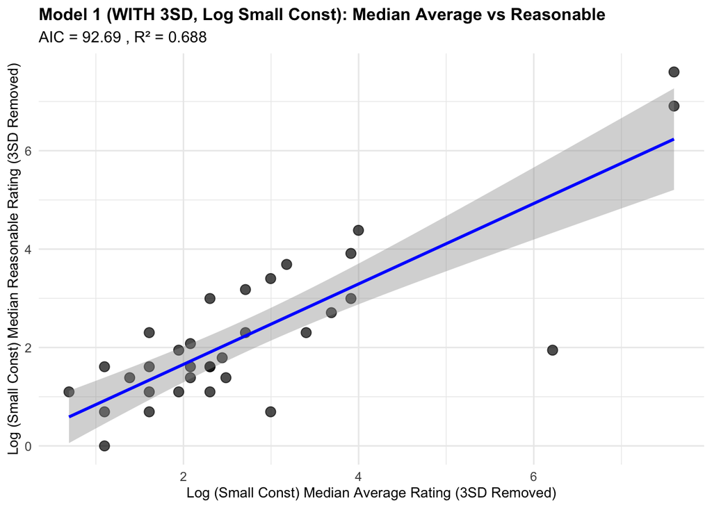

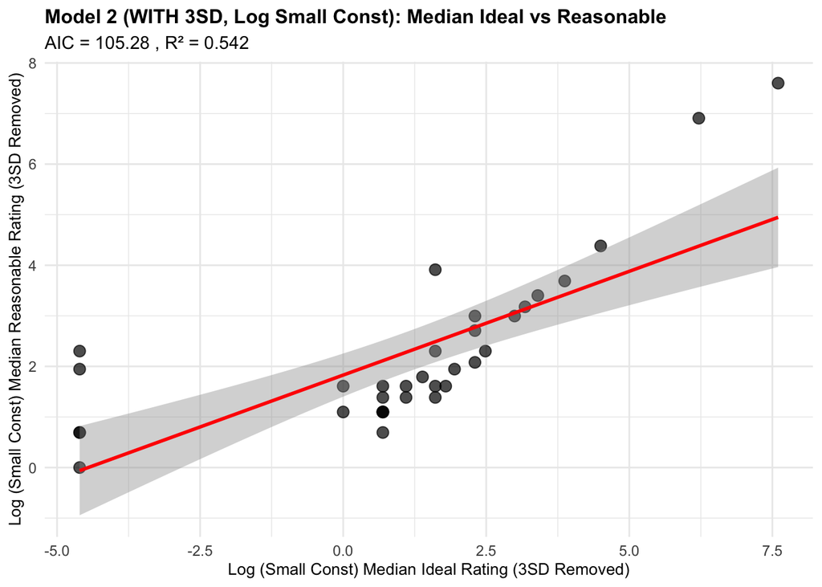

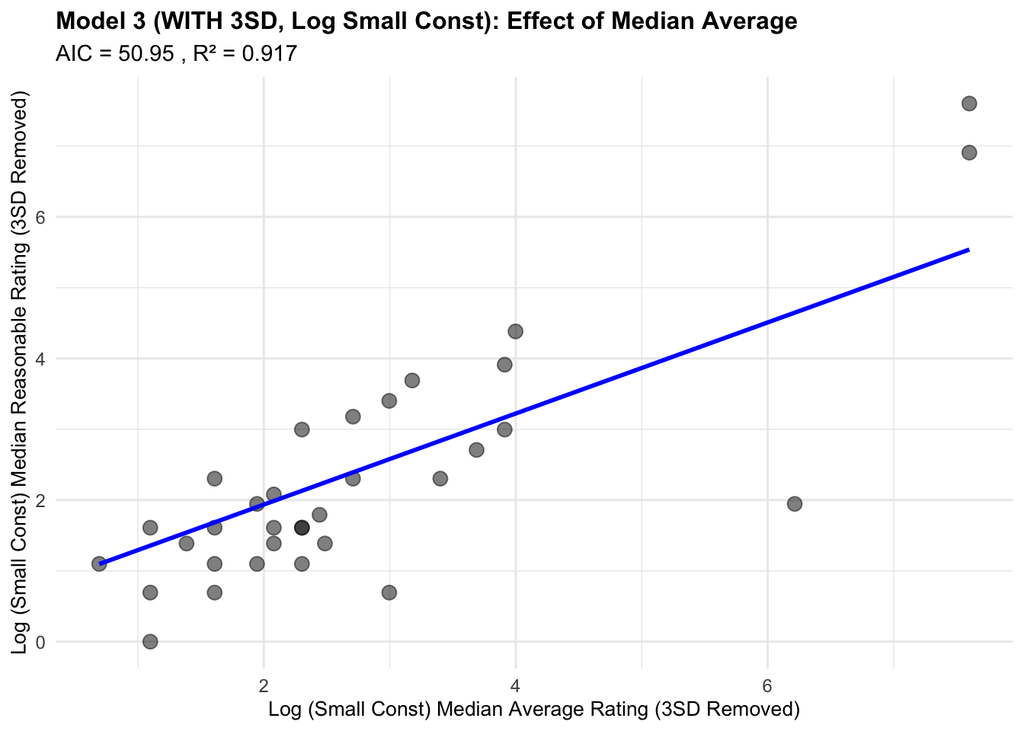

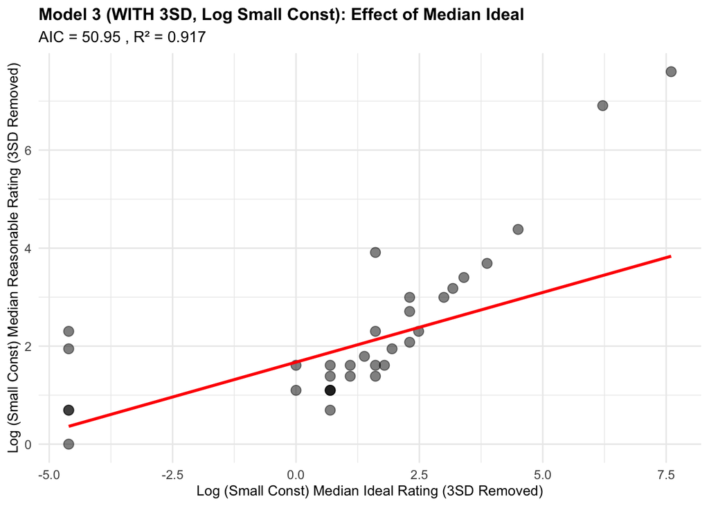

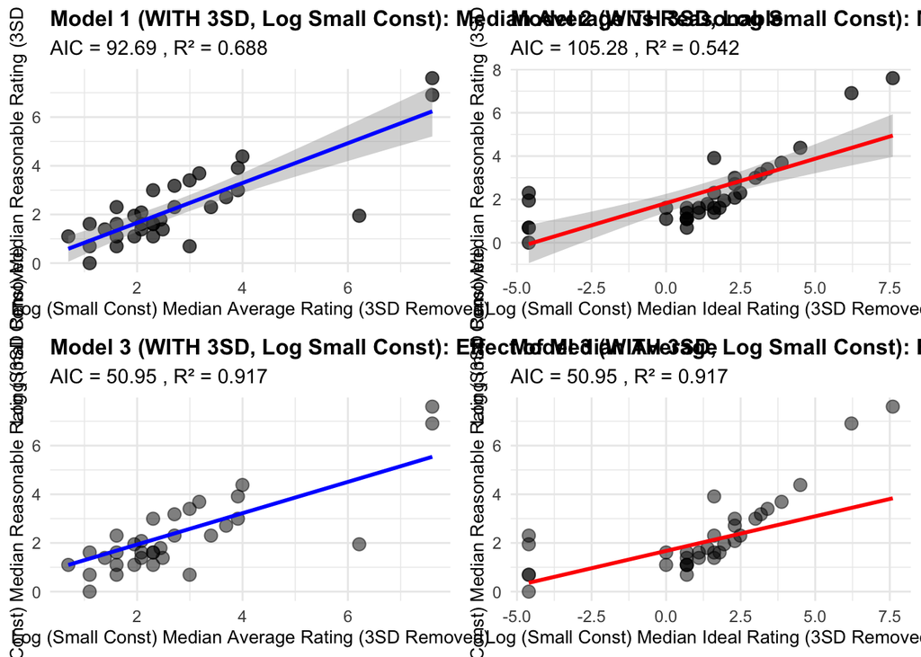

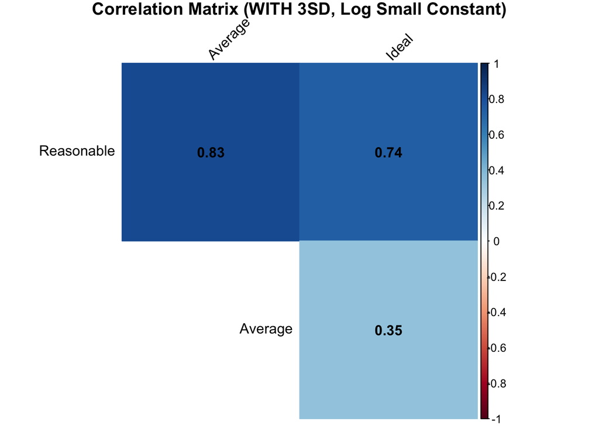

```
##
## Model Summaries (WITH 3SD, Log Small Constant):
##
## Call:
## lm(formula = Reasonable ~ Average, data = dataforAICMedians_3sd_smallval_clean)
##
## Residuals:
##     Min      1Q  Median      3Q     Max
## -3.1568 -0.3358 -0.1127  0.6892  1.3648
##
## Coefficients:
##             Estimate Std. Error t value Pr(>|t|)
## (Intercept)  0.02213    0.31715   0.070    0.945
## Average      0.81753    0.09896   8.261 2.49e-09 ***
## ---
## Signif. codes:  0 '***' 0.001 '**' 0.01 '*' 0.05 '.' 0.1 ' ' 1
##
## Residual standard error: 0.9284 on 31 degrees of freedom
## Multiple R-squared:  0.6876, Adjusted R-squared:  0.6776
## F-statistic: 68.24 on 1 and 31 DF,  p-value: 2.486e-09
##
##
## Call:
## lm(formula = Reasonable ~ Ideal, data = dataforAICMedians_3sd_smallval_clean)
##
## Residuals:
##     Min      1Q  Median      3Q     Max
## -1.4195 -0.7295 -0.2187  0.2721  2.6536
##
## Coefficients:
##             Estimate Std. Error t value Pr(>|t|)
## (Intercept)  1.82816    0.20911   8.743 7.16e-10 ***
## Ideal        0.41036    0.06769   6.063 1.03e-06 ***
## ---
## Signif. codes:  0 '***' 0.001 '**' 0.01 '*' 0.05 '.' 0.1 ' ' 1
##
## Residual standard error: 1.124 on 31 degrees of freedom
## Multiple R-squared:  0.5425, Adjusted R-squared:  0.5277
## F-statistic: 36.76 on 1 and 31 DF,  p-value: 1.027e-06
##
##
## Call:
## lm(formula = Reasonable ~ Average + Ideal, data = dataforAICMedians_3sd_smallval_clean)
##
## Residuals:
##      Min       1Q   Median       3Q      Max
## -0.93341 -0.36561 -0.06373  0.34015  1.23273
##
## Coefficients:
##             Estimate Std. Error t value Pr(>|t|)
## (Intercept)  0.19225    0.16724   1.150    0.259
## Average      0.64316    0.05528  11.634 1.20e-12 ***
## Ideal        0.28444    0.03124   9.104 3.88e-10 ***
## ---
## Signif. codes:  0 '***' 0.001 '**' 0.01 '*' 0.05 '.' 0.1 ' ' 1
##
## Residual standard error: 0.4865 on 30 degrees of freedom
## Multiple R-squared:  0.917,  Adjusted R-squared:  0.9115
## F-statistic: 165.7 on 2 and 30 DF,  p-value: < 2.2e-16
```

```r
# Check if models exist before plotting
if(exists("Model1Medians_3sd_smallval") && exists("dataforAICMedians_3sd_smallval_clean") && nrow(dataforAICMedians_3sd_smallval_clean) > 0) {

  # Average Median vs Reasonable Median
  plot1_median_3sd_smallval <- ggplot(dataforAICMedians_3sd_smallval_clean, aes(x = Average, y = Reasonable)) +
    geom_point(size = 3, alpha = 0.7) + geom_smooth(method = "lm", se = TRUE, color = "blue") +
    labs(title = "Model 1 (WITH 3SD, Log Small Const): Median Average vs Reasonable",
         subtitle = paste("AIC =", round(AIC1Medians_3sd_smallval, 2), ", R² =", round(r2_model1_median_3sd_smallval, 3)),
         x = "Log (Small Const) Median Average Rating (3SD Removed)",
         y = "Log (Small Const) Median Reasonable Rating (3SD Removed)") +
    theme_minimal() + theme( plot.title = element_text(size = 12, face = "bold"), plot.subtitle = element_text(size = 11), axis.title = element_text(size = 10), axis.text = element_text(size = 9) )

  # Ideal Median vs Reasonable Median
  plot2_median_3sd_smallval <- ggplot(dataforAICMedians_3sd_smallval_clean, aes(x = Ideal, y = Reasonable)) +
    geom_point(size = 3, alpha = 0.7) + geom_smooth(method = "lm", se = TRUE, color = "red") +
    labs(title = "Model 2 (WITH 3SD, Log Small Const): Median Ideal vs Reasonable",
         subtitle = paste("AIC =", round(AIC2Medians_3sd_smallval, 2), ", R² =", round(r2_model2_median_3sd_smallval, 3)),
         x = "Log (Small Const) Median Ideal Rating (3SD Removed)",
         y = "Log (Small Const) Median Reasonable Rating (3SD Removed)") +
    theme_minimal() + theme( plot.title = element_text(size = 12, face = "bold"), plot.subtitle = element_text(size = 11), axis.title = element_text(size = 10), axis.text = element_text(size = 9) )

  # Model 3 (Average effect)
  new_data_median_3sd_smallval <- expand.grid( Average = seq(min(dataforAICMedians_3sd_smallval_clean$Average, na.rm=TRUE), max(dataforAICMedians_3sd_smallval_clean$Average, na.rm=TRUE), length.out = 100), Ideal = median(dataforAICMedians_3sd_smallval_clean$Ideal, na.rm=TRUE) )
  new_data_median_3sd_smallval <- new_data_median_3sd_smallval[is.finite(new_data_median_3sd_smallval$Average) & is.finite(new_data_median_3sd_smallval$Ideal),]
  if(nrow(new_data_median_3sd_smallval)>0){ new_data_median_3sd_smallval$predicted_reasonable <- predict(Model3Medians_3sd_smallval, newdata = new_data_median_3sd_smallval) } else { new_data_median_3sd_smallval <- data.frame(Average=numeric(), Ideal=numeric(), predicted_reasonable=numeric()) }
  plot3_median_3sd_smallval <- ggplot(dataforAICMedians_3sd_smallval_clean, aes(x = Average, y = Reasonable)) + geom_point(size = 3, alpha = 0.5) + geom_line(data = new_data_median_3sd_smallval, aes(y = predicted_reasonable), color = "blue", size = 1) + labs(title = "Model 3 (WITH 3SD, Log Small Const): Effect of Median Average", subtitle = paste("AIC =", round(AIC3Medians_3sd_smallval, 2), ", R² =", round(r2_model3_median_3sd_smallval, 3)), x = "Log (Small Const) Median Average Rating (3SD Removed)", y = "Log (Small Const) Median Reasonable Rating (3SD Removed)") + theme_minimal() + theme( plot.title = element_text(size = 12, face = "bold"), plot.subtitle = element_text(size = 11), axis.title = element_text(size = 10), axis.text = element_text(size = 9) )

  # Model 3 (Ideal effect)
  new_data2_median_3sd_smallval <- expand.grid( Average = median(dataforAICMedians_3sd_smallval_clean$Average, na.rm=TRUE), Ideal = seq(min(dataforAICMedians_3sd_smallval_clean$Ideal, na.rm=TRUE), max(dataforAICMedians_3sd_smallval_clean$Ideal, na.rm=TRUE), length.out = 100) )
  new_data2_median_3sd_smallval <- new_data2_median_3sd_smallval[is.finite(new_data2_median_3sd_smallval$Average) & is.finite(new_data2_median_3sd_smallval$Ideal),]
  if(nrow(new_data2_median_3sd_smallval)>0){ new_data2_median_3sd_smallval$predicted_reasonable <- predict(Model3Medians_3sd_smallval, newdata = new_data2_median_3sd_smallval) } else { new_data2_median_3sd_smallval <- data.frame(Average=numeric(), Ideal=numeric(), predicted_reasonable=numeric()) }
  plot4_median_3sd_smallval <- ggplot(dataforAICMedians_3sd_smallval_clean, aes(x = Ideal, y = Reasonable)) + geom_point(size = 3, alpha = 0.5) + geom_line(data = new_data2_median_3sd_smallval, aes(y = predicted_reasonable), color = "red", size = 1) + labs(title = "Model 3 (WITH 3SD, Log Small Const): Effect of Median Ideal", subtitle = paste("AIC =", round(AIC3Medians_3sd_smallval, 2), ", R² =", round(r2_model3_median_3sd_smallval, 3)), x = "Log (Small Const) Median Ideal Rating (3SD Removed)", y = "Log (Small Const) Median Reasonable Rating (3SD Removed)") + theme_minimal() + theme( plot.title = element_text(size = 12, face = "bold"), plot.subtitle = element_text(size = 11), axis.title = element_text(size = 10), axis.text = element_text(size = 9) )

  # Display plots
  print(plot1_median_3sd_smallval)
  print(plot2_median_3sd_smallval)
  print(plot3_median_3sd_smallval)
  print(plot4_median_3sd_smallval)

  # Save plots
  ggsave("model1_median_avg_reas_3sd_smallval.png", plot1_median_3sd_smallval, width = 8, height = 6, dpi = 300)
  ggsave("model2_median_ideal_reas_3sd_smallval.png", plot2_median_3sd_smallval, width = 8, height = 6, dpi = 300)
  ggsave("model3_median_avg_eff_3sd_smallval.png", plot3_median_3sd_smallval, width = 8, height = 6, dpi = 300)
  ggsave("model3_median_ideal_eff_3sd_smallval.png", plot4_median_3sd_smallval, width = 8, height = 6, dpi = 300)
  grid_plots_median_3sd_smallval <- grid.arrange(plot1_median_3sd_smallval, plot2_median_3sd_smallval, plot3_median_3sd_smallval, plot4_median_3sd_smallval, ncol = 2)
  ggsave("all_median_plots_3sd_smallval.png", grid_plots_median_3sd_smallval, width = 14, height = 10, dpi = 300)

  # Correlation matrix
  cor_data_3sd_smallval <- dataforAICMedians_3sd_smallval_clean[complete.cases(dataforAICMedians_3sd_smallval_clean),]
  if(nrow(cor_data_3sd_smallval) > 1) {
   cor_matrix_3sd_smallval <- cor(cor_data_3sd_smallval, use = "complete.obs")
   corrplot(cor_matrix_3sd_smallval, method = "color", type = "upper", addCoef.col = "black", tl.col = "black", tl.srt = 45, diag = FALSE, title = "Correlation Matrix (WITH 3SD, Log Small Constant)", mar = c(0,0,1,0))
  } else { cat("Not enough data for correlation matrix (WITH 3SD, Log Small Constant).\n") }

  # Coefficient tables
  model1_coefs_3sd_smallval <- get_model_coefs(Model1Medians_3sd_smallval)
  model2_coefs_3sd_smallval <- get_model_coefs(Model2Medians_3sd_smallval)
  model3_coefs_3sd_smallval <- get_model_coefs(Model3Medians_3sd_smallval)
  model1_coefs_3sd_smallval$p_value <- sapply(model1_coefs_3sd_smallval$p_value, format_pvalue)
  model2_coefs_3sd_smallval$p_value <- sapply(model2_coefs_3sd_smallval$p_value, format_pvalue)
  model3_coefs_3sd_smallval$p_value <- sapply(model3_coefs_3sd_smallval$p_value, format_pvalue)
  kable(model1_coefs_3sd_smallval, caption = "Model 1 Coeffs (WITH 3SD, Log Small Const)") %>% kable_styling(bootstrap_options = c("striped", "hover", "condensed"), full_width = F)
  kable(model2_coefs_3sd_smallval, caption = "Model 2 Coeffs (WITH 3SD, Log Small Const)") %>% kable_styling(bootstrap_options = c("striped", "hover", "condensed"), full_width = F)
  kable(model3_coefs_3sd_smallval, caption = "Model 3 Coeffs (WITH 3SD, Log Small Const)") %>% kable_styling(bootstrap_options = c("striped", "hover", "condensed"), full_width = F)

  # Print model summaries
  cat("\nModel Summaries (WITH 3SD, Log Small Constant):\n")
  print(summary(Model1Medians_3sd_smallval))
  print(summary(Model2Medians_3sd_smallval))
  print(summary(Model3Medians_3sd_smallval))

} else {
   cat("Skipping plots and summaries for (WITH 3SD, Log Small Constant) due to insufficient data.\n")
}
```

```r
# Store results
analysis_3_results_3sd_smallval <- list(
  medians_by_question = if(exists("medians_df_3sd")) medians_df_3sd else NULL,
  log_medians_by_question = if(exists("log_medians_df_3sd_smallval")) log_medians_df_3sd_smallval else NULL,
  regression_models = if(exists("Model1Medians_3sd_smallval")) list(model1 = Model1Medians_3sd_smallval, model2 = Model2Medians_3sd_smallval, model3 = Model3Medians_3sd_smallval) else NULL,
  regression_summary = if(exists("regression_summary_medians_3sd_smallval")) regression_summary_medians_3sd_smallval else NULL,
  aic_values = if(exists("AIC1Medians_3sd_smallval")) c(AIC1 = AIC1Medians_3sd_smallval, AIC2 = AIC2Medians_3sd_smallval, AIC3 = AIC3Medians_3sd_smallval) else NULL
)
```

#### 4b. (Plus one to all values): Plots and Reporting (WITH 3SD Removal)

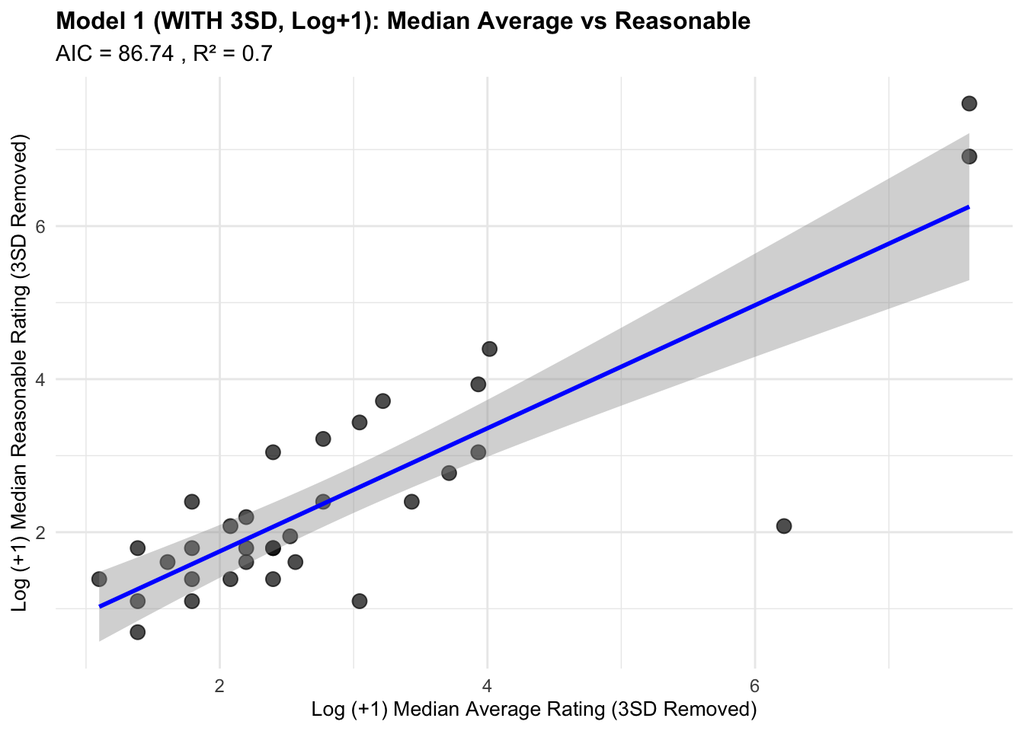

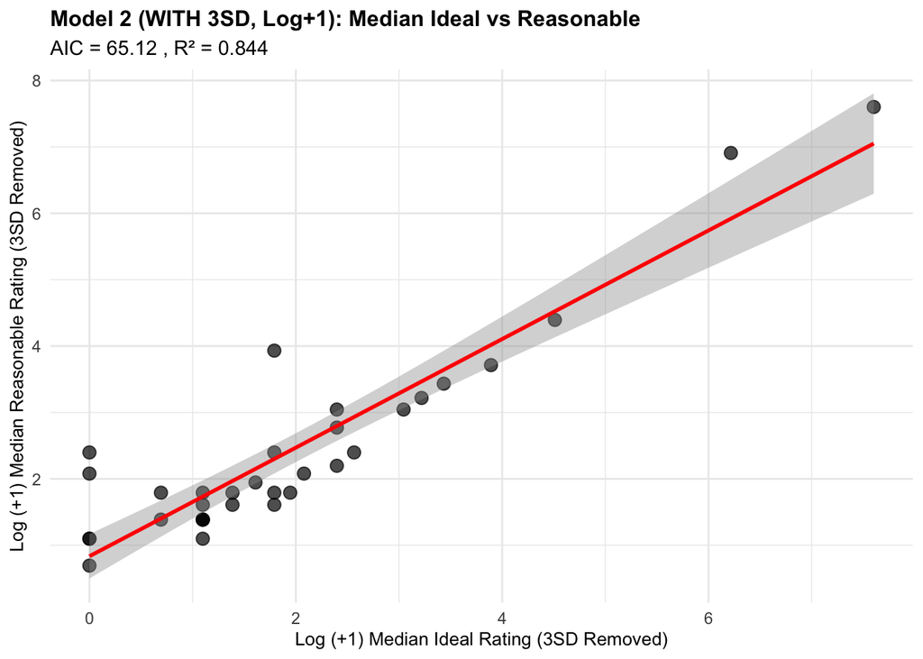

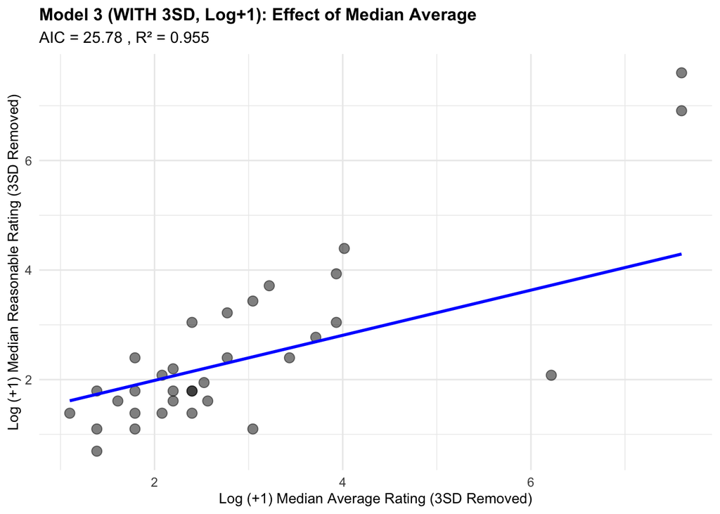

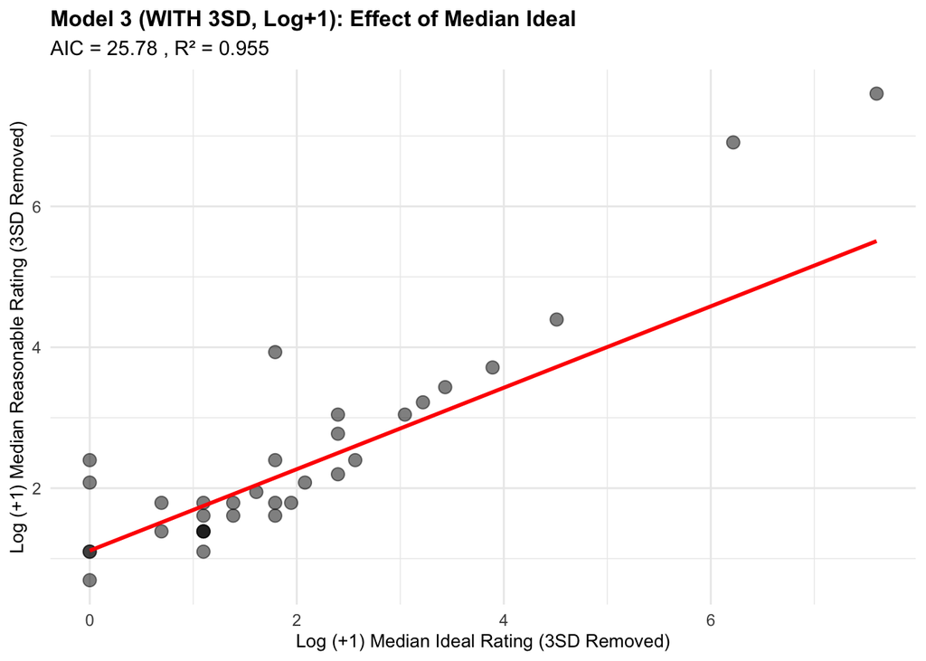

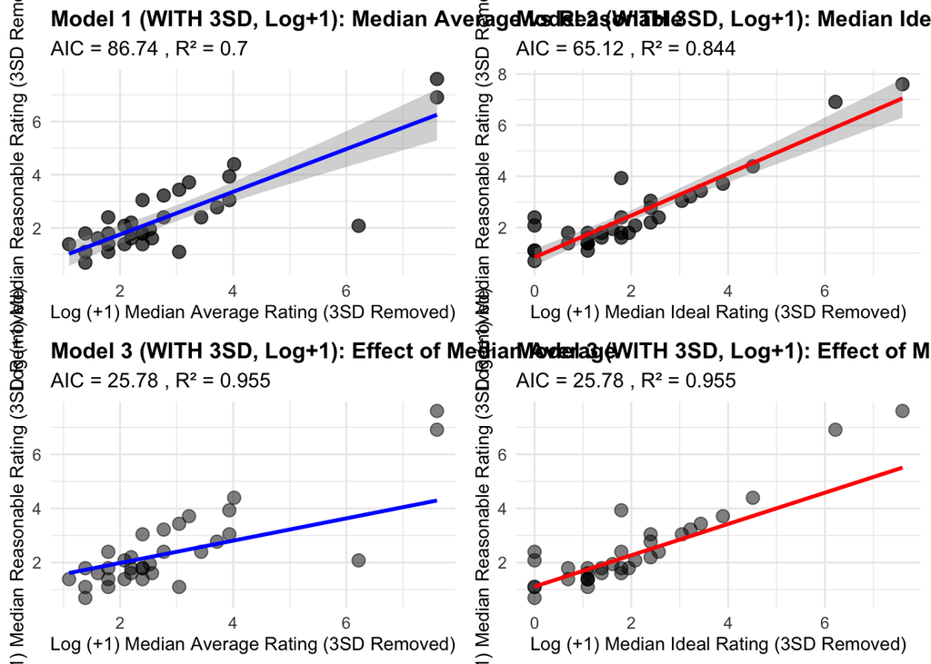

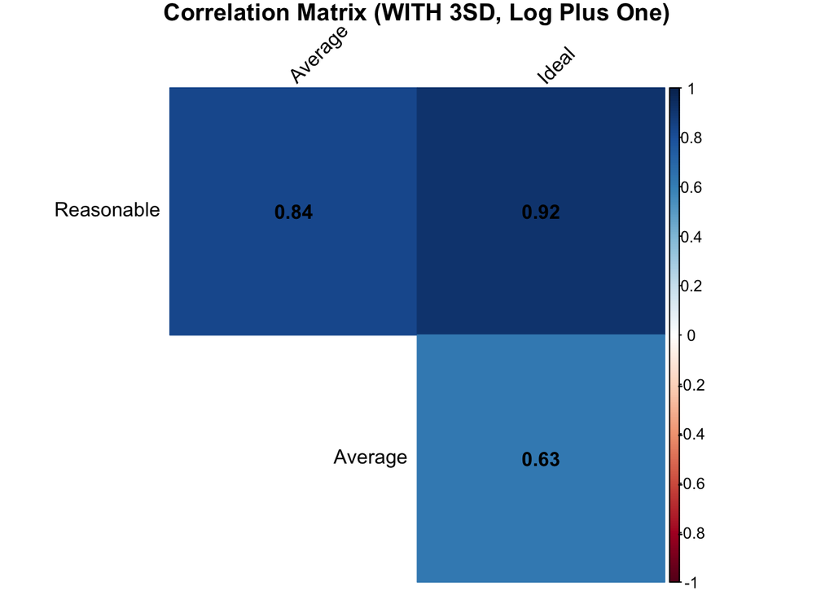

```
##
## Model Summaries (WITH 3SD, Log Plus One):
##
## Call:
## lm(formula = Reasonable ~ Average, data = dataforAICMedians_3sd_plusone_clean)
##
## Residuals:
##     Min      1Q  Median      3Q     Max
## -3.0611 -0.3553 -0.1168  0.6285  1.3474
##
## Coefficients:
##             Estimate Std. Error t value Pr(>|t|)
## (Intercept)  0.14186    0.30917   0.459     0.65
## Average      0.80408    0.09458   8.501 1.33e-09 ***
## ---
## Signif. codes:  0 '***' 0.001 '**' 0.01 '*' 0.05 '.' 0.1 ' ' 1
##
## Residual standard error: 0.8484 on 31 degrees of freedom
## Multiple R-squared:  0.6998, Adjusted R-squared:  0.6901
## F-statistic: 72.27 on 1 and 31 DF,  p-value: 1.331e-09
##
##
## Call:
## lm(formula = Reasonable ~ Ideal, data = dataforAICMedians_3sd_plusone_clean)
##
## Residuals:
##     Min      1Q  Median      3Q     Max
## -0.6903 -0.3466 -0.1764  0.2491  1.6321
##
## Coefficients:
##             Estimate Std. Error t value Pr(>|t|)
## (Intercept)  0.83447    0.16400   5.088 1.67e-05 ***
## Ideal        0.81779    0.06312  12.956 4.74e-14 ***
## ---
## Signif. codes:  0 '***' 0.001 '**' 0.01 '*' 0.05 '.' 0.1 ' ' 1
##
## Residual standard error: 0.6114 on 31 degrees of freedom
## Multiple R-squared:  0.8441, Adjusted R-squared:  0.8391
## F-statistic: 167.9 on 1 and 31 DF,  p-value: 4.742e-14
##
##
## Call:
## lm(formula = Reasonable ~ Average + Ideal, data = dataforAICMedians_3sd_plusone_clean)
##
## Residuals:
##      Min       1Q   Median       3Q      Max
## -0.60695 -0.21446 -0.02932  0.09051  1.15093
##
## Coefficients:
##             Estimate Std. Error t value Pr(>|t|)
## (Intercept)  0.12470    0.12108   1.030    0.311
## Average      0.41207    0.04759   8.659 1.17e-09 ***
## Ideal        0.57820    0.04407  13.120 5.81e-14 ***
## ---
## Signif. codes:  0 '***' 0.001 '**' 0.01 '*' 0.05 '.' 0.1 ' ' 1
##
## Residual standard error: 0.3322 on 30 degrees of freedom
## Multiple R-squared:  0.9555, Adjusted R-squared:  0.9525
## F-statistic: 321.7 on 2 and 30 DF,  p-value: < 2.2e-16
```

```r
# Check if models exist before plotting
if(exists("Model1Medians_3sd_plusone") && exists("dataforAICMedians_3sd_plusone_clean") && nrow(dataforAICMedians_3sd_plusone_clean) > 0) {

  # Average Median vs Reasonable Median
  plot1_median_3sd_plusone <- ggplot(dataforAICMedians_3sd_plusone_clean, aes(x = Average, y = Reasonable)) +
    geom_point(size = 3, alpha = 0.7) + geom_smooth(method = "lm", se = TRUE, color = "blue") +
    labs(title = "Model 1 (WITH 3SD, Log+1): Median Average vs Reasonable",
         subtitle = paste("AIC =", round(AIC1Medians_3sd_plusone, 2), ", R² =", round(r2_model1_median_3sd_plusone, 3)),
         x = "Log (+1) Median Average Rating (3SD Removed)",
         y = "Log (+1) Median Reasonable Rating (3SD Removed)") +
    theme_minimal() + theme( plot.title = element_text(size = 12, face = "bold"), plot.subtitle = element_text(size = 11), axis.title = element_text(size = 10), axis.text = element_text(size = 9) )

  # Ideal Median vs Reasonable Median
  plot2_median_3sd_plusone <- ggplot(dataforAICMedians_3sd_plusone_clean, aes(x = Ideal, y = Reasonable)) +
    geom_point(size = 3, alpha = 0.7) + geom_smooth(method = "lm", se = TRUE, color = "red") +
    labs(title = "Model 2 (WITH 3SD, Log+1): Median Ideal vs Reasonable",
         subtitle = paste("AIC =", round(AIC2Medians_3sd_plusone, 2), ", R² =", round(r2_model2_median_3sd_plusone, 3)),
         x = "Log (+1) Median Ideal Rating (3SD Removed)",
         y = "Log (+1) Median Reasonable Rating (3SD Removed)") +
    theme_minimal() + theme( plot.title = element_text(size = 12, face = "bold"), plot.subtitle = element_text(size = 11), axis.title = element_text(size = 10), axis.text = element_text(size = 9) )

  # Model 3 (Average effect)
  new_data_median_3sd_plusone <- expand.grid( Average = seq(min(dataforAICMedians_3sd_plusone_clean$Average, na.rm=TRUE), max(dataforAICMedians_3sd_plusone_clean$Average, na.rm=TRUE), length.out = 100), Ideal = median(dataforAICMedians_3sd_plusone_clean$Ideal, na.rm=TRUE) )
  new_data_median_3sd_plusone <- new_data_median_3sd_plusone[is.finite(new_data_median_3sd_plusone$Average) & is.finite(new_data_median_3sd_plusone$Ideal),]
  if(nrow(new_data_median_3sd_plusone)>0){ new_data_median_3sd_plusone$predicted_reasonable <- predict(Model3Medians_3sd_plusone, newdata = new_data_median_3sd_plusone) } else { new_data_median_3sd_plusone <- data.frame(Average=numeric(), Ideal=numeric(), predicted_reasonable=numeric()) }
  plot3_median_3sd_plusone <- ggplot(dataforAICMedians_3sd_plusone_clean, aes(x = Average, y = Reasonable)) + geom_point(size = 3, alpha = 0.5) + geom_line(data = new_data_median_3sd_plusone, aes(y = predicted_reasonable), color = "blue", size = 1) + labs(title = "Model 3 (WITH 3SD, Log+1): Effect of Median Average", subtitle = paste("AIC =", round(AIC3Medians_3sd_plusone, 2), ", R² =", round(r2_model3_median_3sd_plusone, 3)), x = "Log (+1) Median Average Rating (3SD Removed)", y = "Log (+1) Median Reasonable Rating (3SD Removed)") + theme_minimal() + theme( plot.title = element_text(size = 12, face = "bold"), plot.subtitle = element_text(size = 11), axis.title = element_text(size = 10), axis.text = element_text(size = 9) )

  # Model 3 (Ideal effect)
  new_data2_median_3sd_plusone <- expand.grid( Average = median(dataforAICMedians_3sd_plusone_clean$Average, na.rm=TRUE), Ideal = seq(min(dataforAICMedians_3sd_plusone_clean$Ideal, na.rm=TRUE), max(dataforAICMedians_3sd_plusone_clean$Ideal, na.rm=TRUE), length.out = 100) )
  new_data2_median_3sd_plusone <- new_data2_median_3sd_plusone[is.finite(new_data2_median_3sd_plusone$Average) & is.finite(new_data2_median_3sd_plusone$Ideal),]
  if(nrow(new_data2_median_3sd_plusone)>0){ new_data2_median_3sd_plusone$predicted_reasonable <- predict(Model3Medians_3sd_plusone, newdata = new_data2_median_3sd_plusone) } else { new_data2_median_3sd_plusone <- data.frame(Average=numeric(), Ideal=numeric(), predicted_reasonable=numeric()) }
  plot4_median_3sd_plusone <- ggplot(dataforAICMedians_3sd_plusone_clean, aes(x = Ideal, y = Reasonable)) + geom_point(size = 3, alpha = 0.5) + geom_line(data = new_data2_median_3sd_plusone, aes(y = predicted_reasonable), color = "red", size = 1) + labs(title = "Model 3 (WITH 3SD, Log+1): Effect of Median Ideal", subtitle = paste("AIC =", round(AIC3Medians_3sd_plusone, 2), ", R² =", round(r2_model3_median_3sd_plusone, 3)), x = "Log (+1) Median Ideal Rating (3SD Removed)", y = "Log (+1) Median Reasonable Rating (3SD Removed)") + theme_minimal() + theme( plot.title = element_text(size = 12, face = "bold"), plot.subtitle = element_text(size = 11), axis.title = element_text(size = 10), axis.text = element_text(size = 9) )

  # Display plots
  print(plot1_median_3sd_plusone)
  print(plot2_median_3sd_plusone)
  print(plot3_median_3sd_plusone)
  print(plot4_median_3sd_plusone)

  # Save plots
  ggsave("model1_median_avg_reas_3sd_plusone.png", plot1_median_3sd_plusone, width = 8, height = 6, dpi = 300)
  ggsave("model2_median_ideal_reas_3sd_plusone.png", plot2_median_3sd_plusone, width = 8, height = 6, dpi = 300)
  ggsave("model3_median_avg_eff_3sd_plusone.png", plot3_median_3sd_plusone, width = 8, height = 6, dpi = 300)
  ggsave("model3_median_ideal_eff_3sd_plusone.png", plot4_median_3sd_plusone, width = 8, height = 6, dpi = 300)
  grid_plots_median_3sd_plusone <- grid.arrange(plot1_median_3sd_plusone, plot2_median_3sd_plusone, plot3_median_3sd_plusone, plot4_median_3sd_plusone, ncol = 2)
  ggsave("all_median_plots_3sd_plusone.png", grid_plots_median_3sd_plusone, width = 14, height = 10, dpi = 300)

  # Correlation matrix
  cor_data_3sd_plusone <- dataforAICMedians_3sd_plusone_clean[complete.cases(dataforAICMedians_3sd_plusone_clean),]
  if(nrow(cor_data_3sd_plusone) > 1) {
   cor_matrix_3sd_plusone <- cor(cor_data_3sd_plusone, use = "complete.obs")
   corrplot(cor_matrix_3sd_plusone, method = "color", type = "upper", addCoef.col = "black", tl.col = "black", tl.srt = 45, diag = FALSE, title = "Correlation Matrix (WITH 3SD, Log Plus One)", mar = c(0,0,1,0))
  } else { cat("Not enough data for correlation matrix (WITH 3SD, Log Plus One).\n") }

  # Coefficient tables
  model1_coefs_3sd_plusone <- get_model_coefs(Model1Medians_3sd_plusone)
  model2_coefs_3sd_plusone <- get_model_coefs(Model2Medians_3sd_plusone)
  model3_coefs_3sd_plusone <- get_model_coefs(Model3Medians_3sd_plusone)
  model1_coefs_3sd_plusone$p_value <- sapply(model1_coefs_3sd_plusone$p_value, format_pvalue)
  model2_coefs_3sd_plusone$p_value <- sapply(model2_coefs_3sd_plusone$p_value, format_pvalue)
  model3_coefs_3sd_plusone$p_value <- sapply(model3_coefs_3sd_plusone$p_value, format_pvalue)
  kable(model1_coefs_3sd_plusone, caption = "Model 1 Coeffs (WITH 3SD, Log Plus One)") %>% kable_styling(bootstrap_options = c("striped", "hover", "condensed"), full_width = F)
  kable(model2_coefs_3sd_plusone, caption = "Model 2 Coeffs (WITH 3SD, Log Plus One)") %>% kable_styling(bootstrap_options = c("striped", "hover", "condensed"), full_width = F)
  kable(model3_coefs_3sd_plusone, caption = "Model 3 Coeffs (WITH 3SD, Log Plus One)") %>% kable_styling(bootstrap_options = c("striped", "hover", "condensed"), full_width = F)

  # Print model summaries
  cat("\nModel Summaries (WITH 3SD, Log Plus One):\n")
  print(summary(Model1Medians_3sd_plusone))
  print(summary(Model2Medians_3sd_plusone))
  print(summary(Model3Medians_3sd_plusone))

} else {
  cat("Skipping plots and summaries for (WITH 3SD, Log Plus One) due to insufficient data.\n")
}
```

```r
# Store results
analysis_3_results_3sd_plusone <- list(
  medians_by_question = if(exists("medians_df_3sd")) medians_df_3sd else NULL,
  log_medians_by_question = if(exists("log_medians_df_3sd_plusone")) log_medians_df_3sd_plusone else NULL,
  regression_models = if(exists("Model1Medians_3sd_plusone")) list(model1 = Model1Medians_3sd_plusone, model2 = Model2Medians_3sd_plusone, model3 = Model3Medians_3sd_plusone) else NULL,
  regression_summary = if(exists("regression_summary_medians_3sd_plusone")) regression_summary_medians_3sd_plusone else NULL,
  aic_values = if(exists("AIC1Medians_3sd_plusone")) c(AIC1 = AIC1Medians_3sd_plusone, AIC2 = AIC2Medians_3sd_plusone, AIC3 = AIC3Medians_3sd_plusone) else NULL
)
```

# Analysis 4 [NO 3 SD Outlier Removal]: Overall results, intermediacy with median ratings

Step 1 and Step 2 have been completed in the earlier analysis.

#### Functions for Analysis 4

```r
# Function to check if reasonable is on the "ideal side" of average
# Equal median ratings are treated as being on the predicted side
is_ideal_side_median <- function(average, ideal, reasonable) {
  if (any(is.na(c(average, ideal, reasonable)))) {
    return(NA)
  }
  # Check if distance to ideal is less than or equal to distance to average
  ifelse(abs(reasonable - ideal) <= abs(reasonable - average), 1, 0)
}

# Function to check if reasonable is on the "average side" of ideal
# Equal median ratings are treated as being on the predicted side
is_average_side_median <- function(average, ideal, reasonable) {
  if (any(is.na(c(average, ideal, reasonable)))) {
      return(NA)
  }
  # Check if distance to average is less than or equal to distance to ideal
  ifelse(abs(reasonable - average) <= abs(reasonable - ideal), 1, 0)
}

# Function to check if reasonable falls between average and ideal (inclusive/liberal)
# Handles cases where average == ideal
is_both_sides_median_liberal <- function(average, ideal, reasonable) {
  if (any(is.na(c(average, ideal, reasonable)))) {
      return(NA)
  }
  # Check if reasonable is numerically between average and ideal, inclusive
  # This works regardless of whether average > ideal or ideal > average
  ifelse((reasonable >= min(average, ideal)) & (reasonable <= max(average, ideal)), 1, 0)
}

# Function to check if reasonable falls between average and ideal (conservative)
# Handles cases where average is NOT == ideal
is_both_sides_median_conservative <- function(average, ideal, reasonable) {
  if (any(is.na(c(average, ideal, reasonable)))) {
    return(NA)
  }
  # Check if reasonable is numerically between average and ideal, conservative
  ifelse((reasonable > min(average, ideal)) & (reasonable < max(average, ideal)), 1, 0)
}
```

#### Steps 3, 4, 5: Intermediacy Calculations (NO 3SD Removal)

```r
# --- Calculate all vectors ---
ideal_side_vector_median_no3sd <- mapply(is_ideal_side_median, column_medians_average_no3sd, column_medians_ideal_no3sd, column_medians_reasonable_no3sd)
average_side_vector_median_no3sd <- mapply(is_average_side_median, column_medians_average_no3sd, column_medians_ideal_no3sd, column_medians_reasonable_no3sd)
both_sides_vector_median_no3sd_liberal <- mapply(is_both_sides_median_liberal, column_medians_average_no3sd, column_medians_ideal_no3sd, column_medians_reasonable_no3sd)
both_sides_vector_median_no3sd_conservative <- mapply(is_both_sides_median_conservative, column_medians_average_no3sd, column_medians_ideal_no3sd, column_medians_reasonable_no3sd)

# --- Calculate counts and valid Ns ---
count_ideal_side_median_no3sd <- sum(ideal_side_vector_median_no3sd, na.rm = TRUE)
valid_questions_ideal_no3sd <- sum(!is.na(ideal_side_vector_median_no3sd))
count_average_side_median_no3sd <- sum(average_side_vector_median_no3sd, na.rm = TRUE)
valid_questions_avg_no3sd <- sum(!is.na(average_side_vector_median_no3sd))
count_both_sides_median_no3sd_liberal <- sum(both_sides_vector_median_no3sd_liberal, na.rm = TRUE)
valid_questions_both_no3sd_liberal <- sum(!is.na(both_sides_vector_median_no3sd_liberal))
count_both_sides_median_no3sd_conservative <- sum(both_sides_vector_median_no3sd_conservative, na.rm = TRUE)
valid_questions_both_no3sd_conservative <- sum(!is.na(both_sides_vector_median_no3sd_conservative))

# --- Perform binomial tests ---
p_val_ideal_no3sd <- NA;
if (valid_questions_ideal_no3sd > 0) {
  binomial_result_ideal_median_no3sd <- binom.test(count_ideal_side_median_no3sd, valid_questions_ideal_no3sd, p = 0.5, alternative = "greater")
  p_val_ideal_no3sd <- binomial_result_ideal_median_no3sd$p.value
}

p_val_avg_no3sd <- NA;
if (valid_questions_avg_no3sd > 0) {
  binomial_result_avg_side_median_no3sd <- binom.test(count_average_side_median_no3sd, valid_questions_avg_no3sd, p = 0.5, alternative = "greater")
  p_val_avg_no3sd <- binomial_result_avg_side_median_no3sd$p.value
}

p_val_both_liberal_no3sd <- NA;
if (valid_questions_both_no3sd_liberal > 0) {
  binomial_result_both_sides_liberal_median_no3sd <- binom.test(count_both_sides_median_no3sd_liberal, valid_questions_both_no3sd_liberal, p = 1/3, alternative = "two.sided")
  p_val_both_liberal_no3sd <- binomial_result_both_sides_liberal_median_no3sd$p.value
}

p_val_both_conservative_no3sd <- NA;
if (valid_questions_both_no3sd_conservative > 0) {
  binomial_result_both_sides_conservative_median_no3sd <- binom.test(count_both_sides_median_no3sd_conservative, valid_questions_both_no3sd_conservative, p = 1/3, alternative = "two.sided")
  p_val_both_conservative_no3sd <- binomial_result_both_sides_conservative_median_no3sd$p.value
}

# --- Create ONE combined summary table ---
intermediacy_summary_no3sd <- data.frame(
  Test = c("On Ideal Side of Average", "On Average Side of Ideal", "Between (Liberal)", "Between (Conservative)"),
  Count = c(count_ideal_side_median_no3sd, count_average_side_median_no3sd, count_both_sides_median_no3sd_liberal, count_both_sides_median_no3sd_conservative),
  Total_Valid = c(valid_questions_ideal_no3sd, valid_questions_avg_no3sd, valid_questions_both_no3sd_liberal, valid_questions_both_no3sd_conservative),
  Expected_Prop = c(0.5, 0.5, 1/3, 1/3),
  p_value = c(p_val_ideal_no3sd, p_val_avg_no3sd, p_val_both_liberal_no3sd, p_val_both_conservative_no3sd)
)

# Format proportions and p-values
intermediacy_summary_no3sd$Proportion <- scales::percent(intermediacy_summary_no3sd$Count / intermediacy_summary_no3sd$Total_Valid, accuracy = 0.1)
intermediacy_summary_no3sd$Expected_Prop <- scales::percent(intermediacy_summary_no3sd$Expected_Prop, accuracy = 0.1)
intermediacy_summary_no3sd$p_value <- sapply(intermediacy_summary_no3sd$p_value, format_pvalue)

# Display the summary table
kable(intermediacy_summary_no3sd[,c("Test", "Count", "Total_Valid", "Proportion", "Expected_Prop", "p_value")],
      caption = "Intermediacy Binomial Tests (NO 3SD Removal)") %>%
  kable_styling(bootstrap_options = c("striped", "hover", "condensed"), full_width = F)
```

Intermediacy Binomial Tests (NO 3SD Removal)

| Test | Count | Total_Valid | Proportion | Expected_Prop | p_value |
| --- | --- | --- | --- | --- | --- |
| On Ideal Side of Average | 29 | 33 | 87.9% | 50.0% | < .001 |
| On Average Side of Ideal | 8 | 33 | 24.2% | 50.0% | .999 |
| Between (Liberal) | 31 | 33 | 93.9% | 33.3% | < .001 |
| Between (Conservative) | 20 | 33 | 60.6% | 33.3% | .001 |

#### 6. Plots and Reporting (Intermediacy - Median Analysis, NO 3SD Removed)

```r
# Create a table showing the results for each question, including both intermediacy measures
question_position_summary_median_no3sd <- data.frame(
  Question = names(column_medians_average_no3sd),
  Average_Value = column_medians_average_no3sd,
  Ideal_Value = column_medians_ideal_no3sd,
  Reasonable_Value = column_medians_reasonable_no3sd,
  On_Ideal_Side = ideal_side_vector_median_no3sd,
  On_Average_Side = average_side_vector_median_no3sd,
  Between_Liberal = both_sides_vector_median_no3sd_liberal,
  Between_Conservative = both_sides_vector_median_no3sd_conservative
)

# Categorize for Liberal Analysis
question_position_summary_median_no3sd$Position_Liberal <- "Other/NA"
question_position_summary_median_no3sd$Position_Liberal[question_position_summary_median_no3sd$Between_Liberal == 1] <- "Between (Liberal)"
question_position_summary_median_no3sd$Position_Liberal[question_position_summary_median_no3sd$Between_Liberal == 0 & question_position_summary_median_no3sd$On_Ideal_Side == 1 & question_position_summary_median_no3sd$On_Average_Side == 0] <- "Beyond Ideal"
question_position_summary_median_no3sd$Position_Liberal[question_position_summary_median_no3sd$Between_Liberal == 0 & question_position_summary_median_no3sd$On_Average_Side == 1 & question_position_summary_median_no3sd$On_Ideal_Side == 0] <- "Beyond Average"
question_position_summary_median_no3sd$Position_Liberal[
    !is.na(question_position_summary_median_no3sd$Average_Value) &
    !is.na(question_position_summary_median_no3sd$Ideal_Value) &
    question_position_summary_median_no3sd$Average_Value == question_position_summary_median_no3sd$Ideal_Value] <- "Average = Ideal"

# Categorize for Conservative Analysis
question_position_summary_median_no3sd$Position_Conservative <- "Other/NA"
question_position_summary_median_no3sd$Position_Conservative[question_position_summary_median_no3sd$Between_Conservative == 1] <- "Between (Conservative)"
question_position_summary_median_no3sd$Position_Conservative[question_position_summary_median_no3sd$Between_Conservative == 0 & question_position_summary_median_no3sd$On_Ideal_Side == 1 & question_position_summary_median_no3sd$On_Average_Side == 0] <- "Beyond Ideal"
question_position_summary_median_no3sd$Position_Conservative[question_position_summary_median_no3sd$Between_Conservative == 0 & question_position_summary_median_no3sd$On_Average_Side == 1 & question_position_summary_median_no3sd$On_Ideal_Side == 0] <- "Beyond Average"
question_position_summary_median_no3sd$Position_Conservative[
    !is.na(question_position_summary_median_no3sd$Average_Value) &
    !is.na(question_position_summary_median_no3sd$Ideal_Value) &
    question_position_summary_median_no3sd$Average_Value == question_position_summary_median_no3sd$Ideal_Value] <- "Average = Ideal"


# Display the question position summary table
kable(question_position_summary_median_no3sd[, c("Question", "Average_Value", "Ideal_Value", "Reasonable_Value", "Position_Liberal", "Position_Conservative")],
      caption = "Position of Median Reasonable Rating (NO 3SD Removal) Relative to Average and Ideal") %>%
  kable_styling(bootstrap_options = c("striped", "hover", "condensed"), full_width = F)
```

Position of Median Reasonable Rating (NO 3SD Removal) Relative to Average and Ideal

|  | Question | Average_Value | Ideal_Value | Reasonable_Value | Position_Liberal | Position_Conservative |
| --- | --- | --- | --- | --- | --- | --- |
| q1 | q1 | 3.0 | 2.0 | 2.0 | Between (Liberal) | Beyond Ideal |
| q2 | q2 | 7.0 | 2.0 | 4.0 | Between (Liberal) | Between (Conservative) |
| q3 | q3 | 3.0 | 6.0 | 5.0 | Between (Liberal) | Between (Conservative) |
| q4 | q4 | 2000.0 | 2000.0 | 2000.0 | Average = Ideal | Average = Ideal |
| q5 | q5 | 20.0 | 30.0 | 30.0 | Between (Liberal) | Beyond Ideal |
| q6 | q6 | 10.0 | 1.0 | 3.0 | Between (Liberal) | Between (Conservative) |
| q7 | q7 | 15.0 | 5.0 | 10.0 | Between (Liberal) | Between (Conservative) |
| q8 | q8 | 5.0 | 12.0 | 10.0 | Between (Liberal) | Between (Conservative) |
| q9 | q9 | 5.0 | 3.0 | 5.0 | Between (Liberal) | Beyond Average |
| q10 | q10 | 5.0 | 0.0 | 2.0 | Between (Liberal) | Between (Conservative) |
| q11 | q11 | 500.0 | 0.0 | 10.0 | Between (Liberal) | Between (Conservative) |
| q12 | q12 | 30.0 | 1.0 | 10.0 | Between (Liberal) | Between (Conservative) |
| q13 | q13 | 40.0 | 10.0 | 15.0 | Between (Liberal) | Between (Conservative) |
| q14 | q14 | 10.0 | 2.0 | 5.0 | Between (Liberal) | Between (Conservative) |
| q15 | q15 | 9.0 | 10.0 | 8.0 | Beyond Average | Beyond Average |
| q16 | q16 | 5.0 | 5.0 | 4.0 | Average = Ideal | Average = Ideal |
| q17 | q17 | 3.0 | 0.0 | 1.0 | Between (Liberal) | Between (Conservative) |
| q18 | q18 | 15.0 | 2.0 | 9.5 | Between (Liberal) | Between (Conservative) |
| q20 | q20 | 20.0 | 0.0 | 4.0 | Between (Liberal) | Between (Conservative) |
| q21 | q21 | 8.0 | 5.0 | 5.0 | Between (Liberal) | Beyond Ideal |
| q22 | q22 | 10.0 | 7.0 | 7.0 | Between (Liberal) | Beyond Ideal |
| q23 | q23 | 2.0 | 3.0 | 3.0 | Between (Liberal) | Beyond Ideal |
| q24 | q24 | 16.0 | 24.0 | 24.0 | Between (Liberal) | Beyond Ideal |
| q25 | q25 | 2000.0 | 500.0 | 1000.0 | Between (Liberal) | Between (Conservative) |
| q26 | q26 | 8.0 | 2.0 | 4.0 | Between (Liberal) | Between (Conservative) |
| q27 | q27 | 12.0 | 5.0 | 6.0 | Between (Liberal) | Between (Conservative) |
| q28 | q28 | 10.0 | 20.0 | 20.0 | Between (Liberal) | Beyond Ideal |
| q29 | q29 | 55.0 | 90.0 | 80.0 | Between (Liberal) | Between (Conservative) |
| q30 | q30 | 12.0 | 4.0 | 4.0 | Between (Liberal) | Beyond Ideal |
| q31 | q31 | 50.0 | 13.0 | 25.0 | Between (Liberal) | Between (Conservative) |
| q32 | q32 | 24.0 | 48.0 | 40.0 | Between (Liberal) | Between (Conservative) |
| q33 | q33 | 5.5 | 2.5 | 4.0 | Between (Liberal) | Between (Conservative) |
| q34 | q34 | 50.0 | 10.0 | 50.0 | Between (Liberal) | Beyond Average |

```r
# --- Liberal Distribution ---
position_counts_liberal_no3sd <- as.data.frame(table(question_position_summary_median_no3sd$Position_Liberal))
names(position_counts_liberal_no3sd) <- c("Position", "Count")
kable(position_counts_liberal_no3sd, caption = "Distribution of Position Categories (Liberal, NO 3SD Removal)") %>%
  kable_styling(bootstrap_options = c("striped", "hover", "condensed"), full_width = F)
```

Distribution of Position Categories (Liberal, NO 3SD Removal)

| Position | Count |
| --- | --- |
| Average = Ideal | 2 |
| Between (Liberal) | 30 |
| Beyond Average | 1 |

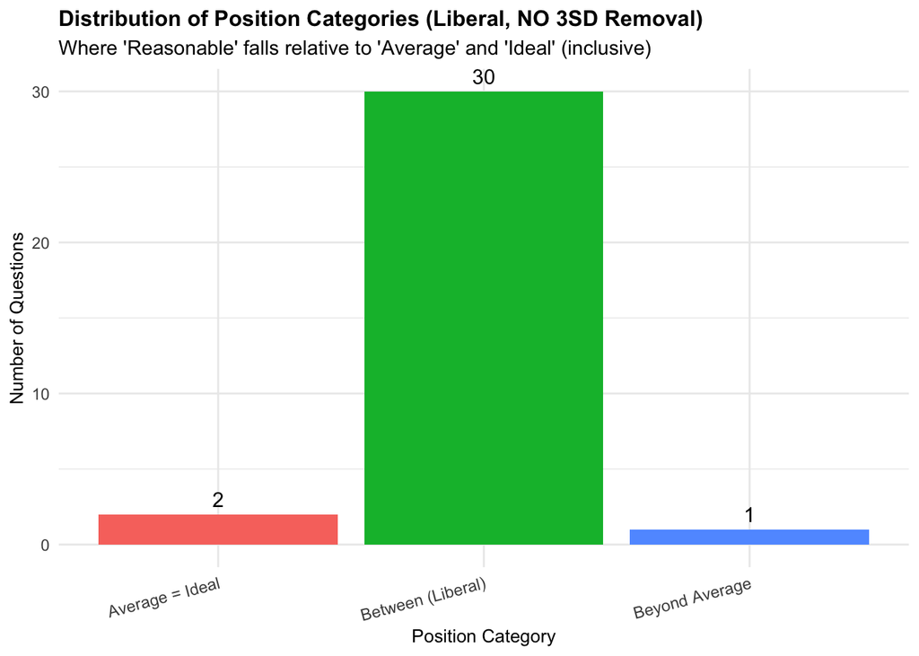

```r
position_distribution_plot_liberal_no3sd <- ggplot(position_counts_liberal_no3sd, aes(x = Position, y = Count, fill = Position)) +
  geom_bar(stat = "identity") +
  geom_text(aes(label = paste0(Count)), vjust = -0.5, size = 4) +
  labs(title = "Distribution of Position Categories (Liberal, NO 3SD Removal)",
       subtitle = "Where 'Reasonable' falls relative to 'Average' and 'Ideal' (inclusive)",
       x = "Position Category", y = "Number of Questions") +
  theme_minimal() + theme( plot.title = element_text(size = 12, face = "bold"), plot.subtitle = element_text(size = 11), axis.title = element_text(size = 10), axis.text.x = element_text(size = 9, angle = 15, hjust = 1), legend.position = "none")
print(position_distribution_plot_liberal_no3sd)
```

```r
ggsave("position_distribution_median_liberal_no3sd.png", position_distribution_plot_liberal_no3sd, width = 10, height = 7, dpi = 300)


# --- Conservative Distribution ---
position_counts_conservative_no3sd <- as.data.frame(table(question_position_summary_median_no3sd$Position_Conservative))
names(position_counts_conservative_no3sd) <- c("Position", "Count")
kable(position_counts_conservative_no3sd, caption = "Distribution of Position Categories (Conservative, NO 3SD Removal)") %>%
  kable_styling(bootstrap_options = c("striped", "hover", "condensed"), full_width = F)
```

Distribution of Position Categories (Conservative, NO 3SD Removal)

| Position | Count |
| --- | --- |
| Average = Ideal | 2 |
| Between (Conservative) | 20 |
| Beyond Average | 3 |
| Beyond Ideal | 8 |

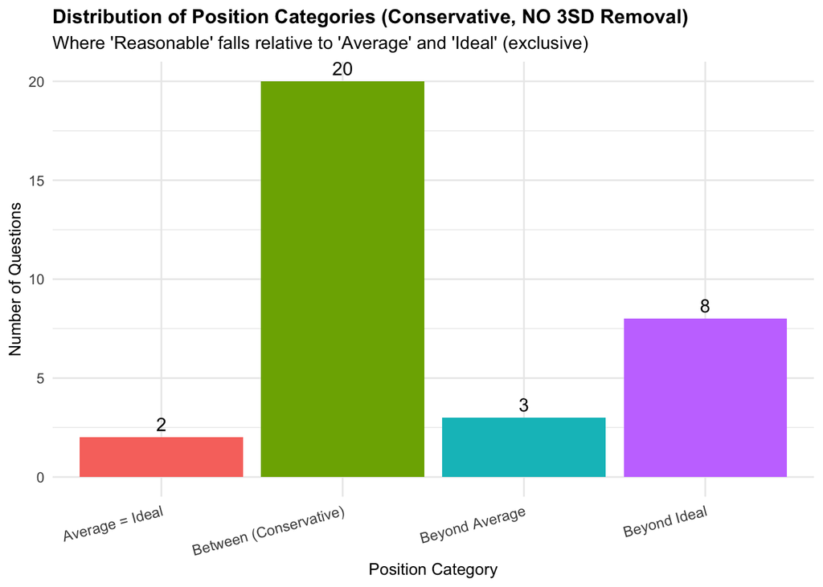

```r
position_distribution_plot_conservative_no3sd <- ggplot(position_counts_conservative_no3sd, aes(x = Position, y = Count, fill = Position)) +
  geom_bar(stat = "identity") +
  geom_text(aes(label = paste0(Count)), vjust = -0.5, size = 4) +
  labs(title = "Distribution of Position Categories (Conservative, NO 3SD Removal)",
       subtitle = "Where 'Reasonable' falls relative to 'Average' and 'Ideal' (exclusive)",
       x = "Position Category", y = "Number of Questions") +
  theme_minimal() + theme( plot.title = element_text(size = 12, face = "bold"), plot.subtitle = element_text(size = 11), axis.title = element_text(size = 10), axis.text.x = element_text(size = 9, angle = 15, hjust = 1), legend.position = "none")
print(position_distribution_plot_conservative_no3sd)
```

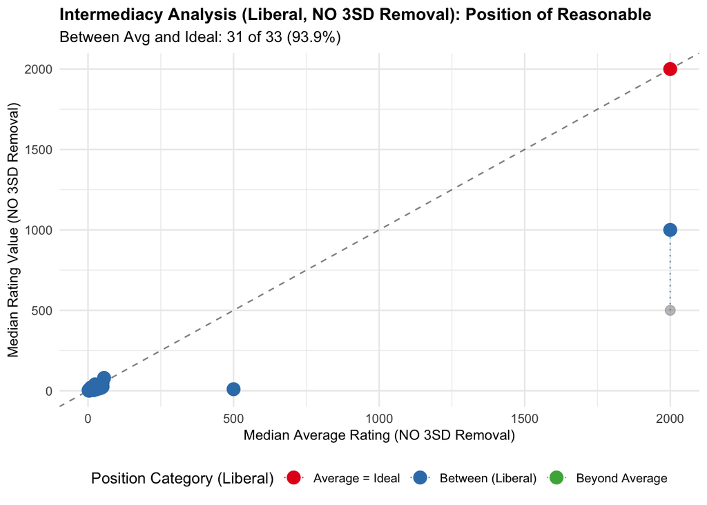

```r
ggsave("position_distribution_median_conservative_no3sd.png", position_distribution_plot_conservative_no3sd, width = 10, height = 7, dpi = 300)

# --- Liberal Scatterplot ---
plot_data_intermediacy_no3sd <- question_position_summary_median_no3sd %>% filter(!is.na(Average_Value) & !is.na(Ideal_Value) & !is.na(Reasonable_Value))
prop_both_liberal_fmt <- scales::percent(ifelse(valid_questions_both_no3sd_liberal > 0, count_both_sides_median_no3sd_liberal/valid_questions_both_no3sd_liberal, 0), accuracy=0.1)

intermediacy_plot_liberal_no3sd <- ggplot(plot_data_intermediacy_no3sd, aes(x = Average_Value, y = Ideal_Value)) +
  geom_abline(intercept = 0, slope = 1, linetype = "dashed", alpha = 0.5) +
  geom_point(color = "gray60", size = 3, alpha = 0.6) +
  geom_point(aes(x = Average_Value, y = Reasonable_Value, color = Position_Liberal), size = 4) +
  geom_segment(aes(x = Average_Value, xend = Average_Value, y = Ideal_Value, yend = Reasonable_Value, color = Position_Liberal), linetype = "dotted", size = 0.5, alpha = 0.7) +
  scale_color_brewer(palette = "Set1") +
  labs(title = "Intermediacy Analysis (Liberal, NO 3SD Removal): Position of Reasonable",
       subtitle = paste0("Between Avg and Ideal: ", count_both_sides_median_no3sd_liberal, " of ", valid_questions_both_no3sd_liberal, " (", prop_both_liberal_fmt, ")"),
       x = "Median Average Rating (NO 3SD Removal)", y = "Median Rating Value (NO 3SD Removal)", color = "Position Category (Liberal)") +
  theme_minimal() + theme(plot.title = element_text(size = 12, face = "bold"), plot.subtitle = element_text(size = 11), axis.title = element_text(size = 10), axis.text = element_text(size = 9), legend.position = "bottom")
print(intermediacy_plot_liberal_no3sd)
```

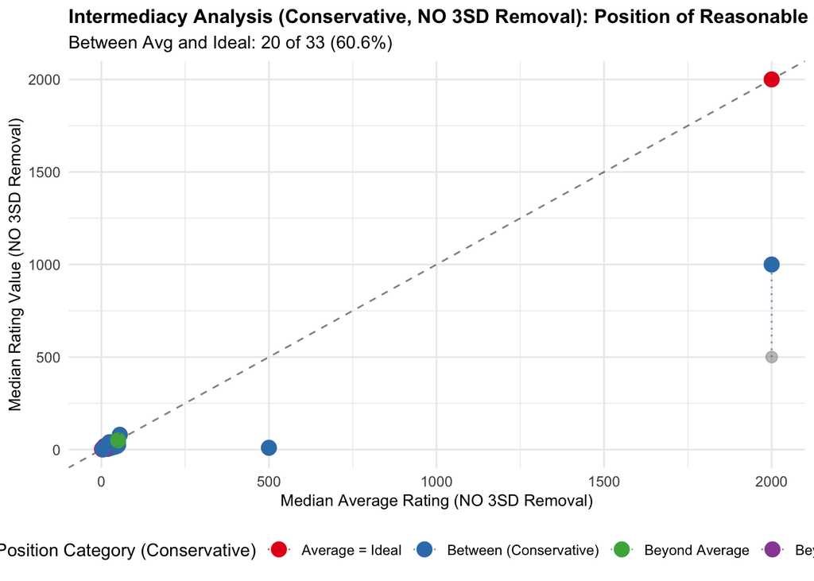

```r
ggsave("intermediacy_analysis_median_liberal_no3sd.png", intermediacy_plot_liberal_no3sd, width = 10, height = 8, dpi = 300)


# --- Conservative Scatterplot ---
prop_both_conservative_fmt <- scales::percent(ifelse(valid_questions_both_no3sd_conservative > 0, count_both_sides_median_no3sd_conservative/valid_questions_both_no3sd_conservative, 0), accuracy=0.1)

intermediacy_plot_conservative_no3sd <- ggplot(plot_data_intermediacy_no3sd, aes(x = Average_Value, y = Ideal_Value)) +
  geom_abline(intercept = 0, slope = 1, linetype = "dashed", alpha = 0.5) +
  geom_point(color = "gray60", size = 3, alpha = 0.6) +
  geom_point(aes(x = Average_Value, y = Reasonable_Value, color = Position_Conservative), size = 4) +
  geom_segment(aes(x = Average_Value, xend = Average_Value, y = Ideal_Value, yend = Reasonable_Value, color = Position_Conservative), linetype = "dotted", size = 0.5, alpha = 0.7) +
  scale_color_brewer(palette = "Set1") +
  labs(title = "Intermediacy Analysis (Conservative, NO 3SD Removal): Position of Reasonable",
       subtitle = paste0("Between Avg and Ideal: ", count_both_sides_median_no3sd_conservative, " of ", valid_questions_both_no3sd_conservative, " (", prop_both_conservative_fmt, ")"),
       x = "Median Average Rating (NO 3SD Removal)", y = "Median Rating Value (NO 3SD Removal)", color = "Position Category (Conservative)") +
  theme_minimal() + theme(plot.title = element_text(size = 12, face = "bold"), plot.subtitle = element_text(size = 11), axis.title = element_text(size = 10), axis.text = element_text(size = 9), legend.position = "bottom")
print(intermediacy_plot_conservative_no3sd)
```

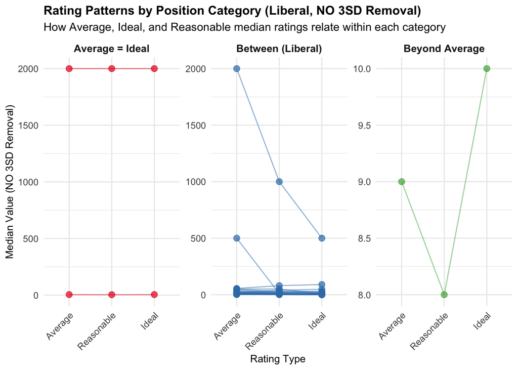

```r
ggsave("intermediacy_analysis_median_conservative_no3sd.png", intermediacy_plot_conservative_no3sd, width = 10, height = 8, dpi = 300)

# --- Liberal Rating Patterns Plot ---
ratings_long_liberal_no3sd <- question_position_summary_median_no3sd %>%
  select(Question, Average_Value, Ideal_Value, Reasonable_Value, Position_Liberal) %>%
  pivot_longer(cols = c(Average_Value, Ideal_Value, Reasonable_Value), names_to = "Rating_Type", values_to = "Value") %>%
  mutate(Rating_Type = factor(gsub("_Value", "", Rating_Type), levels = c("Average", "Reasonable", "Ideal"))) %>%
  filter(!is.na(Value))

rating_patterns_plot_liberal_no3sd <- ggplot(ratings_long_liberal_no3sd, aes(x = Rating_Type, y = Value, group = Question, color = Position_Liberal)) +
  geom_line(alpha = 0.5) + geom_point(size = 2.5, alpha=0.7) + facet_wrap(~ Position_Liberal, scales = "free_y") +
  scale_color_brewer(palette = "Set1") +
  labs(title = "Rating Patterns by Position Category (Liberal, NO 3SD Removal)",
       subtitle = "How Average, Ideal, and Reasonable median ratings relate within each category",
       x = "Rating Type", y = "Median Value (NO 3SD Removal)") +
  theme_minimal() + theme(plot.title = element_text(size = 12, face = "bold"), plot.subtitle = element_text(size = 11), axis.title = element_text(size = 10), axis.text.x = element_text(size = 9, angle = 45, hjust = 1), axis.text.y = element_text(size = 9), strip.text = element_text(size=10, face="bold"), legend.position = "none")
print(rating_patterns_plot_liberal_no3sd)
```

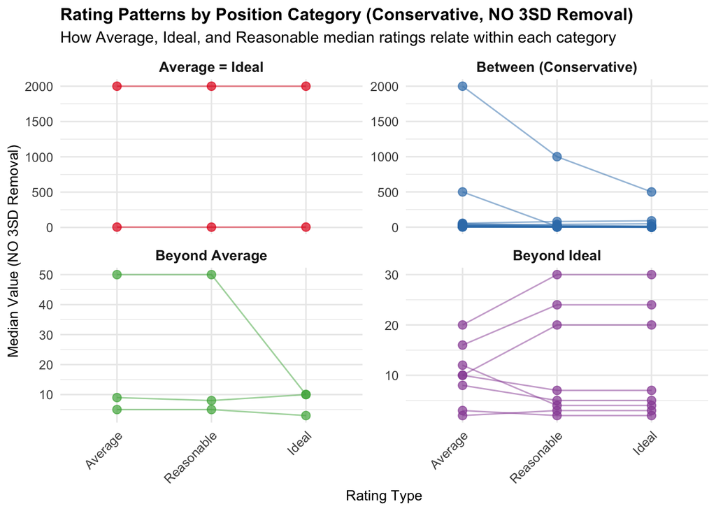

```r
ggsave("rating_patterns_by_position_liberal_no3sd.png", rating_patterns_plot_liberal_no3sd, width = 12, height = 8, dpi = 300)


# --- Conservative Rating Patterns Plot ---
ratings_long_conservative_no3sd <- question_position_summary_median_no3sd %>%
  select(Question, Average_Value, Ideal_Value, Reasonable_Value, Position_Conservative) %>%
  pivot_longer(cols = c(Average_Value, Ideal_Value, Reasonable_Value), names_to = "Rating_Type", values_to = "Value") %>%
  mutate(Rating_Type = factor(gsub("_Value", "", Rating_Type), levels = c("Average", "Reasonable", "Ideal"))) %>%
  filter(!is.na(Value))

rating_patterns_plot_conservative_no3sd <- ggplot(ratings_long_conservative_no3sd, aes(x = Rating_Type, y = Value, group = Question, color = Position_Conservative)) +
  geom_line(alpha = 0.5) + geom_point(size = 2.5, alpha=0.7) + facet_wrap(~ Position_Conservative, scales = "free_y") +
  scale_color_brewer(palette = "Set1") +
  labs(title = "Rating Patterns by Position Category (Conservative, NO 3SD Removal)",
       subtitle = "How Average, Ideal, and Reasonable median ratings relate within each category",
       x = "Rating Type", y = "Median Value (NO 3SD Removal)") +
  theme_minimal() + theme(plot.title = element_text(size = 12, face = "bold"), plot.subtitle = element_text(size = 11), axis.title = element_text(size = 10), axis.text.x = element_text(size = 9, angle = 45, hjust = 1), axis.text.y = element_text(size = 9), strip.text = element_text(size=10, face="bold"), legend.position = "none")
print(rating_patterns_plot_conservative_no3sd)
```

```r
ggsave("rating_patterns_by_position_conservative_no3sd.png", rating_patterns_plot_conservative_no3sd, width = 12, height = 8, dpi = 300)

# Store results for this entire analysis chunk
analysis_4_results_no3sd <- list(
  ideal_side = list(vector=ideal_side_vector_median_no3sd, count=count_ideal_side_median_no3sd, valid_n=valid_questions_ideal_no3sd, binomial_test=binomial_result_ideal_median_no3sd),
  average_side = list(vector=average_side_vector_median_no3sd, count=count_average_side_median_no3sd, valid_n=valid_questions_avg_no3sd, binomial_test=binomial_result_avg_side_median_no3sd),
  both_sides_liberal = list(vector=both_sides_vector_median_no3sd_liberal, count=count_both_sides_median_no3sd_liberal, valid_n=valid_questions_both_no3sd_liberal, binomial_test=binomial_result_both_sides_liberal_median_no3sd),
  both_sides_conservative = list(vector=both_sides_vector_median_no3sd_conservative, count=count_both_sides_median_no3sd_conservative, valid_n=valid_questions_both_no3sd_conservative, binomial_test=binomial_result_both_sides_conservative_median_no3sd),
  combined_summary = intermediacy_summary_no3sd,
  question_position_summary = question_position_summary_median_no3sd
)
```

# Analysis 4 [WITH 3 SD Outlier Removal]: Overall results, intermediacy with median ratings

Step 1 and Step 2 have been completed in the earlier analysis.

#### Functions for Analysis 4

```r
# Function to check if reasonable is on the "ideal side" of average
# Equal median ratings are treated as being on the predicted side
is_ideal_side_median <- function(average, ideal, reasonable) {
  if (any(is.na(c(average, ideal, reasonable)))) {
    return(NA)
  }
  # Check if distance to ideal is less than or equal to distance to average
  ifelse(abs(reasonable - ideal) <= abs(reasonable - average), 1, 0)
}

# Function to check if reasonable is on the "average side" of ideal
# Equal median ratings are treated as being on the predicted side
is_average_side_median <- function(average, ideal, reasonable) {
  if (any(is.na(c(average, ideal, reasonable)))) {
      return(NA)
  }
  # Check if distance to average is less than or equal to distance to ideal
  ifelse(abs(reasonable - average) <= abs(reasonable - ideal), 1, 0)
}

# Function to check if reasonable falls between average and ideal (inclusive/liberal)
# Handles cases where average == ideal
is_both_sides_median_liberal <- function(average, ideal, reasonable) {
  if (any(is.na(c(average, ideal, reasonable)))) {
      return(NA)
  }
  # Check if reasonable is numerically between average and ideal, inclusive
  # This works regardless of whether average > ideal or ideal > average
  ifelse((reasonable >= min(average, ideal)) & (reasonable <= max(average, ideal)), 1, 0)
}

# Function to check if reasonable falls between average and ideal (conservative)
# Handles cases where average is NOT == ideal
is_both_sides_median_conservative <- function(average, ideal, reasonable) {
  if (any(is.na(c(average, ideal, reasonable)))) {
    return(NA)
  }
  # Check if reasonable is numerically between average and ideal, conservative
  ifelse((reasonable > min(average, ideal)) & (reasonable < max(average, ideal)), 1, 0)
}
```

#### Steps 3, 4, 5: Intermediacy Calculations (WITH 3SD Removal)

```r
# --- Calculate all vectors ---
column_medians_average_3sd <- sapply(Data_All_Average_Filtered[, question_cols], median, na.rm = TRUE)
column_medians_ideal_3sd <- sapply(Data_All_Ideal_Filtered[, question_cols], median, na.rm = TRUE)
column_medians_reasonable_3sd <- sapply(Data_All_Reasonable_Filtered[, question_cols], median, na.rm = TRUE)

ideal_side_vector_median_3sd <- mapply(is_ideal_side_median, column_medians_average_3sd, column_medians_ideal_3sd, column_medians_reasonable_3sd)
average_side_vector_median_3sd <- mapply(is_average_side_median, column_medians_average_3sd, column_medians_ideal_3sd, column_medians_reasonable_3sd)
both_sides_vector_median_3sd_liberal <- mapply(is_both_sides_median_liberal, column_medians_average_3sd, column_medians_ideal_3sd, column_medians_reasonable_3sd)
both_sides_vector_median_3sd_conservative <- mapply(is_both_sides_median_conservative, column_medians_average_3sd, column_medians_ideal_3sd, column_medians_reasonable_3sd)

# --- Calculate counts and valid Ns ---
count_ideal_side_median_3sd <- sum(ideal_side_vector_median_3sd, na.rm = TRUE)
valid_questions_ideal_3sd <- sum(!is.na(ideal_side_vector_median_3sd))
count_average_side_median_3sd <- sum(average_side_vector_median_3sd, na.rm = TRUE)
valid_questions_avg_3sd <- sum(!is.na(average_side_vector_median_3sd))
count_both_sides_median_3sd_liberal <- sum(both_sides_vector_median_3sd_liberal, na.rm = TRUE)
valid_questions_both_3sd_liberal <- sum(!is.na(both_sides_vector_median_3sd_liberal))
count_both_sides_median_3sd_conservative <- sum(both_sides_vector_median_3sd_conservative, na.rm = TRUE)
valid_questions_both_3sd_conservative <- sum(!is.na(both_sides_vector_median_3sd_conservative))


# --- Perform binomial tests ---
p_val_ideal_3sd <- NA;
if (valid_questions_ideal_3sd > 0) {
  binomial_result_ideal_median_3sd <- binom.test(count_ideal_side_median_3sd, valid_questions_ideal_3sd, p = 0.5, alternative = "greater")
  p_val_ideal_3sd <- binomial_result_ideal_median_3sd$p.value
}

p_val_avg_3sd <- NA;
if (valid_questions_avg_3sd > 0) {
  binomial_result_avg_side_median_3sd <- binom.test(count_average_side_median_3sd, valid_questions_avg_3sd, p = 0.5, alternative = "greater")
  p_val_avg_3sd <- binomial_result_avg_side_median_3sd$p.value
}

p_val_both_liberal_3sd <- NA;
if (valid_questions_both_3sd_liberal > 0) {
  binomial_result_both_sides_liberal_median_3sd <- binom.test(count_both_sides_median_3sd_liberal, valid_questions_both_3sd_liberal, p = 1/3, alternative = "two.sided")
  p_val_both_liberal_3sd <- binomial_result_both_sides_liberal_median_3sd$p.value
}

p_val_both_conservative_3sd <- NA;
if (valid_questions_both_3sd_conservative > 0) {
  binomial_result_both_sides_conservative_median_3sd <- binom.test(count_both_sides_median_3sd_conservative, valid_questions_both_3sd_conservative, p = 1/3, alternative = "two.sided")
  p_val_both_conservative_3sd <- binomial_result_both_sides_conservative_median_3sd$p.value
}

# --- Create ONE combined summary table for all tests ---
intermediacy_summary_3sd <- data.frame(
  Test = c("On Ideal Side of Average", "On Average Side of Ideal", "Between (Liberal)", "Between (Conservative)"),
  Count = c(count_ideal_side_median_3sd, count_average_side_median_3sd, count_both_sides_median_3sd_liberal, count_both_sides_median_3sd_conservative),
  Total_Valid = c(valid_questions_ideal_3sd, valid_questions_avg_3sd, valid_questions_both_3sd_liberal, valid_questions_both_3sd_conservative),
  Expected_Prop = c(0.5, 0.5, 1/3, 1/3),
  p_value = c(p_val_ideal_3sd, p_val_avg_3sd, p_val_both_liberal_3sd, p_val_both_conservative_3sd)
)

# Calculate and format proportions
intermediacy_summary_3sd$Proportion <- scales::percent(intermediacy_summary_3sd$Count / intermediacy_summary_3sd$Total_Valid, accuracy = 0.1)
intermediacy_summary_3sd$Expected_Prop <- scales::percent(intermediacy_summary_3sd$Expected_Prop, accuracy = 0.1)
intermediacy_summary_3sd$p_value <- sapply(intermediacy_summary_3sd$p_value, format_pvalue)


# Display the summary table
kable(intermediacy_summary_3sd[,c("Test", "Count", "Total_Valid", "Proportion", "Expected_Prop", "p_value")],
      caption = "Intermediacy Binomial Tests (WITH 3SD Removal)") %>%
  kable_styling(bootstrap_options = c("striped", "hover", "condensed"), full_width = F)
```

Intermediacy Binomial Tests (WITH 3SD Removal)

| Test | Count | Total_Valid | Proportion | Expected_Prop | p_value |
| --- | --- | --- | --- | --- | --- |
| On Ideal Side of Average | 29 | 33 | 87.9% | 50.0% | < .001 |
| On Average Side of Ideal | 8 | 33 | 24.2% | 50.0% | .999 |
| Between (Liberal) | 32 | 33 | 97.0% | 33.3% | < .001 |
| Between (Conservative) | 21 | 33 | 63.6% | 33.3% | < .001 |

#### 6. Plots and Reporting (Intermediacy - Median Analysis, WITH 3SD Removed)

```r
# Create a table showing the results for each question, including columns for both liberal and conservative intermediacy
question_position_summary_median_3sd <- data.frame(
  Question = names(column_medians_average_3sd),
  Average_Value = column_medians_average_3sd,
  Ideal_Value = column_medians_ideal_3sd,
  Reasonable_Value = column_medians_reasonable_3sd,
  On_Ideal_Side = ideal_side_vector_median_3sd,
  On_Average_Side = average_side_vector_median_3sd,
  Between_Liberal = both_sides_vector_median_3sd_liberal,
  Between_Conservative = both_sides_vector_median_3sd_conservative
)

# Categorize for Liberal Analysis
question_position_summary_median_3sd$Position_Liberal <- "Other/NA"
question_position_summary_median_3sd$Position_Liberal[question_position_summary_median_3sd$Between_Liberal == 1] <- "Between (Liberal)"
question_position_summary_median_3sd$Position_Liberal[question_position_summary_median_3sd$Between_Liberal == 0 & question_position_summary_median_3sd$On_Ideal_Side == 1 & question_position_summary_median_3sd$On_Average_Side == 0] <- "Beyond Ideal"
question_position_summary_median_3sd$Position_Liberal[question_position_summary_median_3sd$Between_Liberal == 0 & question_position_summary_median_3sd$On_Average_Side == 1 & question_position_summary_median_3sd$On_Ideal_Side == 0] <- "Beyond Average"
question_position_summary_median_3sd$Position_Liberal[
    !is.na(question_position_summary_median_3sd$Average_Value) &
    !is.na(question_position_summary_median_3sd$Ideal_Value) &
    question_position_summary_median_3sd$Average_Value == question_position_summary_median_3sd$Ideal_Value] <- "Average = Ideal"

# Categorize for Conservative Analysis
question_position_summary_median_3sd$Position_Conservative <- "Other/NA"
question_position_summary_median_3sd$Position_Conservative[question_position_summary_median_3sd$Between_Conservative == 1] <- "Between (Conservative)"
question_position_summary_median_3sd$Position_Conservative[question_position_summary_median_3sd$Between_Conservative == 0 & question_position_summary_median_3sd$On_Ideal_Side == 1 & question_position_summary_median_3sd$On_Average_Side == 0] <- "Beyond Ideal"
question_position_summary_median_3sd$Position_Conservative[question_position_summary_median_3sd$Between_Conservative == 0 & question_position_summary_median_3sd$On_Average_Side == 1 & question_position_summary_median_3sd$On_Ideal_Side == 0] <- "Beyond Average"
question_position_summary_median_3sd$Position_Conservative[
    !is.na(question_position_summary_median_3sd$Average_Value) &
    !is.na(question_position_summary_median_3sd$Ideal_Value) &
    question_position_summary_median_3sd$Average_Value == question_position_summary_median_3sd$Ideal_Value] <- "Average = Ideal"


# Display the question position summary table
kable(question_position_summary_median_3sd[, c("Question", "Average_Value", "Ideal_Value", "Reasonable_Value", "Position_Liberal", "Position_Conservative")],
      caption = "Position of Median Reasonable Rating (WITH 3SD Removal) Relative to Average and Ideal") %>%
  kable_styling(bootstrap_options = c("striped", "hover", "condensed"), full_width = F)
```

Position of Median Reasonable Rating (WITH 3SD Removal) Relative to Average and Ideal

|  | Question | Average_Value | Ideal_Value | Reasonable_Value | Position_Liberal | Position_Conservative |
| --- | --- | --- | --- | --- | --- | --- |
| q1 | q1 | 3.0 | 2 | 2 | Between (Liberal) | Beyond Ideal |
| q2 | q2 | 7.0 | 2 | 3 | Between (Liberal) | Between (Conservative) |
| q3 | q3 | 3.0 | 6 | 5 | Between (Liberal) | Between (Conservative) |
| q4 | q4 | 2000.0 | 2000 | 2000 | Average = Ideal | Average = Ideal |
| q5 | q5 | 20.0 | 30 | 30 | Between (Liberal) | Beyond Ideal |
| q6 | q6 | 10.0 | 1 | 3 | Between (Liberal) | Between (Conservative) |
| q7 | q7 | 15.0 | 5 | 10 | Between (Liberal) | Between (Conservative) |
| q8 | q8 | 5.0 | 12 | 10 | Between (Liberal) | Between (Conservative) |
| q9 | q9 | 5.0 | 3 | 5 | Between (Liberal) | Beyond Average |
| q10 | q10 | 5.0 | 0 | 2 | Between (Liberal) | Between (Conservative) |
| q11 | q11 | 500.0 | 0 | 7 | Between (Liberal) | Between (Conservative) |
| q12 | q12 | 30.0 | 0 | 10 | Between (Liberal) | Between (Conservative) |
| q13 | q13 | 40.0 | 10 | 15 | Between (Liberal) | Between (Conservative) |
| q14 | q14 | 10.0 | 2 | 5 | Between (Liberal) | Between (Conservative) |
| q15 | q15 | 8.0 | 10 | 8 | Between (Liberal) | Beyond Average |
| q16 | q16 | 4.0 | 5 | 4 | Between (Liberal) | Beyond Average |
| q17 | q17 | 3.0 | 0 | 1 | Between (Liberal) | Between (Conservative) |
| q18 | q18 | 10.0 | 1 | 5 | Between (Liberal) | Between (Conservative) |
| q20 | q20 | 20.0 | 0 | 2 | Between (Liberal) | Between (Conservative) |
| q21 | q21 | 8.0 | 5 | 5 | Between (Liberal) | Beyond Ideal |
| q22 | q22 | 7.0 | 7 | 7 | Average = Ideal | Average = Ideal |
| q23 | q23 | 2.0 | 2 | 3 | Average = Ideal | Average = Ideal |
| q24 | q24 | 15.0 | 24 | 24 | Between (Liberal) | Beyond Ideal |
| q25 | q25 | 2000.0 | 500 | 1000 | Between (Liberal) | Between (Conservative) |
| q26 | q26 | 8.0 | 2 | 4 | Between (Liberal) | Between (Conservative) |
| q27 | q27 | 11.5 | 4 | 6 | Between (Liberal) | Between (Conservative) |
| q28 | q28 | 10.0 | 20 | 20 | Between (Liberal) | Beyond Ideal |
| q29 | q29 | 54.5 | 90 | 80 | Between (Liberal) | Between (Conservative) |
| q30 | q30 | 12.0 | 3 | 4 | Between (Liberal) | Between (Conservative) |
| q31 | q31 | 50.0 | 10 | 20 | Between (Liberal) | Between (Conservative) |
| q32 | q32 | 24.0 | 48 | 40 | Between (Liberal) | Between (Conservative) |
| q33 | q33 | 5.0 | 2 | 3 | Between (Liberal) | Between (Conservative) |
| q34 | q34 | 50.0 | 5 | 50 | Between (Liberal) | Beyond Average |

```r
# --- Liberal Distribution ---
position_counts_liberal_3sd <- as.data.frame(table(question_position_summary_median_3sd$Position_Liberal))
names(position_counts_liberal_3sd) <- c("Position", "Count")
kable(position_counts_liberal_3sd, caption = "Distribution of Position Categories (Liberal, WITH 3SD Removal)") %>%
  kable_styling(bootstrap_options = c("striped", "hover", "condensed"), full_width = F)
```

Distribution of Position Categories (Liberal, WITH 3SD Removal)

| Position | Count |
| --- | --- |
| Average = Ideal | 3 |
| Between (Liberal) | 30 |

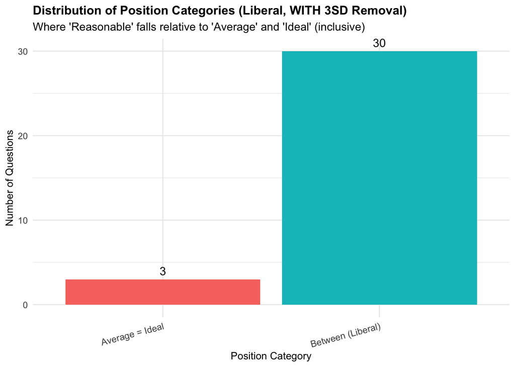

```r
position_distribution_plot_liberal_3sd <- ggplot(position_counts_liberal_3sd, aes(x = Position, y = Count, fill = Position)) +
  geom_bar(stat = "identity") +
  geom_text(aes(label = paste0(Count)), vjust = -0.5, size = 4) +
  labs(title = "Distribution of Position Categories (Liberal, WITH 3SD Removal)",
       subtitle = "Where 'Reasonable' falls relative to 'Average' and 'Ideal' (inclusive)",
       x = "Position Category", y = "Number of Questions") +
  theme_minimal() + theme( plot.title = element_text(size = 12, face = "bold"), plot.subtitle = element_text(size = 11), axis.title = element_text(size = 10), axis.text.x = element_text(size = 9, angle = 15, hjust = 1), legend.position = "none")
print(position_distribution_plot_liberal_3sd)
```

```r
ggsave("position_distribution_median_liberal_3sd_removed.png", position_distribution_plot_liberal_3sd, width = 10, height = 7, dpi = 300)


# --- Conservative Distribution ---
position_counts_conservative_3sd <- as.data.frame(table(question_position_summary_median_3sd$Position_Conservative))
names(position_counts_conservative_3sd) <- c("Position", "Count")
kable(position_counts_conservative_3sd, caption = "Distribution of Position Categories (Conservative, WITH 3SD Removal)") %>%
  kable_styling(bootstrap_options = c("striped", "hover", "condensed"), full_width = F)
```

Distribution of Position Categories (Conservative, WITH 3SD Removal)

| Position | Count |
| --- | --- |
| Average = Ideal | 3 |
| Between (Conservative) | 21 |
| Beyond Average | 4 |
| Beyond Ideal | 5 |